# **DSA 502 — Final Project**

## **AI-Powered Personalized Nutrition Recommendation System**

[🔗 GitHub repository — DSA502-Final-Project-PNRS](https://github.com/Rasy84/DSA502-Final-Project-PNRS)

**Student:** Abu Hanif · **Course:** DSA 502

**Notebook roadmap**

Ingest Excel sources → **clean & audit** → **EDA** → **feature engineering** → **calorie prediction (ML)** → **food & recipe recommendations** → **styled visualizations** → **Ollama + Chroma RAG** for a **RAG-based local AI assistant**. No cloud API keys.

**✔ Final insight:** Color highlights match the chart theme (navy / teal / gold) for a cohesive class presentation.

## **Project overview**

**Why this matters:** People misjudge burn and struggle to translate a calorie number into real foods. This notebook chains **data → model → recommender → grounded AI** so every step is inspectable.

- Predict calories from physiology + session signals (sklearn).
- Recommend foods & recipes aligned to that target (nutrition + recipe tables).
- Explain with a RAG-based local AI assistant (Chroma + `llama3.2` via Ollama).

**✔ Final insight:** Local stack = reproducible for peers grading the GitHub repo.

## **Problem statement**

We need **accurate calorie estimates** from measurable inputs *and* **actionable meal guidance** that respects those estimates—plus a way to **answer questions in natural language** without drifting from the dataset.

- How strongly do duration, heart rate, and body composition explain calories burned?
- Given a target calorie budget, which foods and recipes best match macro quality?
- How can **retrieval + a local LLM** stay faithful to the same rows the tables and plots use?

**✔ Final insight:** The core tension is **numeric fidelity** vs. **human-readable explanation**; RAG bridges them.

# **Dataset Overview**

## **📊 Dataset 1: Exercise and Calories Dataset**

This dataset contains **physiological and exercise-related features** used to predict calorie expenditure. Each row represents a single exercise session.

### **Source**

Kaggle: Calories Burned Prediction Dataset

### **Key Variables**

- User_ID – Unique identifier
- Gender – Biological gender
- Age – Age (years)
- Height – Height (cm)
- Weight – Weight (kg)
- Duration – Exercise duration (minutes)
- Heart_Rate – Heart rate
- Body_Temp – Body temperature
- **Calories – Target variable**

### **Purpose**

Train a **regression model** to predict calorie expenditure.

## **🥗 Dataset 2: Food Nutrition Dataset**

This dataset provides **macronutrient and micronutrient information** for a wide variety of foods.

### **Source**

Kaggle: Food Nutrition Dataset

### **Key Variables**

- Food – Food name
- Calories – Energy value
- Protein – Protein (g)
- Fat – Fat (g)
- Carbohydrates – Carbs (g)
- Fiber – Fiber (g)
- Sugar – Sugar (g)
- Sodium – Sodium (mg)

### **Purpose**

- Recommend foods matching calorie needs
- Compare nutritional profiles
- Support dashboard visualizations

## **🍽 Dataset 3: Recipes Dataset**

Contains recipe-level information including ingredients and preparation details.

### **Purpose**

Extend recommendations from individual foods to **complete meals**.

## ⚠️ **Risks and Limitations**

- Calorie predictions may not capture individual metabolic differences
- Nutrition values may be estimated, not exact
- Dietary preferences and medical conditions are not included
- Possible duplicate or incomplete food entries

## ⚖️ **Ethical Considerations**

- Not a medical tool — should not replace professional advice
- Use as a **decision-support system**
- Consider cultural and dietary differences in real-world use

## **Dataset loading**

The next cell reads every Excel file from the **project folder** (paths are built from `path`). If you clone from GitHub, keep data files beside the notebook or update `path` once.

**Tip:** Run top-to-bottom on a fresh kernel before the Ollama section so all DataFrames exist.

```python
import pandas as pd
import numpy as np
import matplotlib.pyplot as plt
import seaborn as sns

# --- Presentation chart theme (colorful, label-friendly) ---
PRIMARY = "#1f4e79"
ACCENT = "#2e86c1"
GOLD = "#f4b942"
MUTED = "#dde4ef"
sns.set_theme(style="whitegrid", context="notebook", font_scale=1.05)
plt.rcParams.update({
    "figure.facecolor": "#f4f7fb",
    "axes.facecolor": "#ffffff",
    "axes.edgecolor": ACCENT,
    "axes.linewidth": 1.15,
    "axes.titlesize": 14,
    "axes.titleweight": "bold",
    "axes.titlecolor": PRIMARY,
    "axes.labelcolor": "#2c3e50",
    "axes.labelsize": 12,
    "xtick.labelsize": 10,
    "ytick.labelsize": 10,
    "grid.color": MUTED,
    "grid.alpha": 0.75,
    "legend.frameon": True,
    "legend.facecolor": "white",
    "legend.edgecolor": ACCENT,
})

# Folder path
path = r"C:\University Course\DSA 502\Hanif_DSA502_Final Project_AI-Powered Personalized Nutrition Recommendation System"

# -----------------------------------------
# Load exercise and calories datasets
# -----------------------------------------
exercise = pd.read_excel(path + r"\exercise.xlsx")
calories = pd.read_excel(path + r"\calories.xlsx")

# Merge datasets
df = pd.merge(exercise, calories, on="User_ID")

# -----------------------------------------
# Load food nutrition datasets
# -----------------------------------------
food1 = pd.read_excel(path + r"\FOOD-DATA-GROUP1.xlsx")
food2 = pd.read_excel(path + r"\FOOD-DATA-GROUP2.xlsx")
food3 = pd.read_excel(path + r"\FOOD-DATA-GROUP3.xlsx")
food4 = pd.read_excel(path + r"\FOOD-DATA-GROUP4.xlsx")
food5 = pd.read_excel(path + r"\FOOD-DATA-GROUP5.xlsx")

# Combine food datasets
food_df = pd.concat([food1, food2, food3, food4, food5], ignore_index=True)

# -----------------------------------------
# Load recipes dataset
# -----------------------------------------
recipes_df = pd.read_excel(path + r"\Receipes from around the world.xlsx")

# -----------------------------------------
# Preview datasets
# -----------------------------------------
print("Merged calorie dataset:")
display(df.head())

print("Food nutrition dataset:")
display(food_df.head())

print("Recipes dataset:")
display(recipes_df.head())

# -----------------------------------------
# Dataset shapes
# -----------------------------------------
print("Merged dataset shape:", df.shape)
print("Food dataset shape:", food_df.shape)
print("Recipes dataset shape:", recipes_df.shape)
```

```
Merged calorie dataset:
```

|  | User_ID | Gender | Age | Height | Weight | Duration | Heart_Rate | Body_Temp | Calories |
| --- | --- | --- | --- | --- | --- | --- | --- | --- | --- |
| 0 | 14733363 | male | 68 | 190 | 94 | 29 | 105 | 40.8 | 231 |
| 1 | 14861698 | female | 20 | 166 | 60 | 14 | 94 | 40.3 | 66 |
| 2 | 11179863 | male | 69 | 179 | 79 | 5 | 88 | 38.7 | 26 |
| 3 | 16180408 | female | 34 | 179 | 71 | 13 | 100 | 40.5 | 71 |
| 4 | 17771927 | female | 27 | 154 | 58 | 10 | 81 | 39.8 | 35 |

```
Food nutrition dataset:
```

|  | Unnamed: 0.1 | Unnamed: 0 | food | Caloric Value | Fat | Saturated Fats | Monounsaturated Fats | Polyunsaturated Fats | Carbohydrates | Sugars | ... | Calcium | Copper | Iron | Magnesium | Manganese | Phosphorus | Potassium | Selenium | Zinc | Nutrition Density |
| --- | --- | --- | --- | --- | --- | --- | --- | --- | --- | --- | --- | --- | --- | --- | --- | --- | --- | --- | --- | --- | --- |
| 0 | 0 | 0 | cream cheese | 51 | 5.0 | 2.9 | 1.3 | 0.200 | 0.8 | 0.500 | ... | 0.008 | 14.100 | 0.082 | 0.027 | 1.300 | 0.091 | 15.5 | 19.100 | 0.039 | 7.070 |
| 1 | 1 | 1 | neufchatel cheese | 215 | 19.4 | 10.9 | 4.9 | 0.800 | 3.1 | 2.700 | ... | 99.500 | 0.034 | 0.100 | 8.500 | 0.088 | 117.300 | 129.2 | 0.054 | 0.700 | 130.100 |
| 2 | 2 | 2 | requeijao cremoso light catupiry | 49 | 3.6 | 2.3 | 0.9 | 0.000 | 0.9 | 3.400 | ... | 0.000 | 0.000 | 0.000 | 0.000 | 0.000 | 0.000 | 0.0 | 0.000 | 0.000 | 5.400 |
| 3 | 3 | 3 | ricotta cheese | 30 | 2.0 | 1.3 | 0.5 | 0.002 | 1.5 | 0.091 | ... | 0.097 | 41.200 | 0.097 | 0.096 | 4.000 | 0.024 | 30.8 | 43.800 | 0.035 | 5.196 |
| 4 | 4 | 4 | cream cheese low fat | 30 | 2.3 | 1.4 | 0.6 | 0.042 | 1.2 | 0.900 | ... | 22.200 | 0.072 | 0.008 | 1.200 | 0.098 | 22.800 | 37.1 | 0.034 | 0.053 | 27.007 |

5 rows × 37 columns

```
Recipes dataset:
```

|  | recipe_name | cuisine | ingredients | cooking_time_minutes | prep_time_minutes | servings | calories_per_serving | dietary_restrictions |
| --- | --- | --- | --- | --- | --- | --- | --- | --- |
| 0 | Spicy Kimchi Fried Rice | Korean | ['Cooked rice', 'Kimchi', 'Gochujang', 'Soy sa... | 25 | 15 | 2.0 | 450.0 | ['vegetarian'] |
| 1 | Classic Margherita Pizza | Italian | ['Pizza dough', 'Tomato sauce', 'Fresh mozzare... | 20 | 30 | 4.0 | 350.0 | ['vegetarian'] |
| 2 | Coconut Chickpea Curry | Indian | ['Chickpeas', 'Coconut milk', 'Onion', 'Ginger... | 35 | 15 | 4.0 | 480.0 | ['vegan', 'vegetarian', 'gluten-free', 'dairy-... |
| 3 | Pad See Ew with Tofu | Thai | ['Wide rice noodles', 'Tofu', 'Chinese broccol... | 20 | 10 | 2.0 | 520.0 | ['vegetarian'] |
| 4 | Beef Bourguignon | French | ['Beef chuck', 'Red wine', 'Bacon', 'Onion', '... | 150 | 30 | 6.0 | 680.0 | ['nan'] |

```
Merged dataset shape: (15000, 9)
Food dataset shape: (2395, 37)
Recipes dataset shape: (161, 8)
```

## **Dataset Profiling (Post-Load)**

Three tables—**15k sessions**, **2.4k foods**, **161 recipes**—complement each other: prediction, item recommendations, meal ideas.

- **Calorie frame:** balanced gender mix, strong duration signal
- **Nutrition frame:** rich macros; drop stray `Unnamed` columns next
- **Recipes:** global cuisines, dietary tags, a few missing numerics to fix

**✔ Final Insight:** The trio is enough to demo ML, rules, and RAG in one arc.

## **Data Audit**

Shapes, dtypes, missing values, duplicates, and quick descriptive stats—before cleaning and modeling.

```python
# 1. Dataset Shapes
print("===== DATASET SHAPES =====")
print("Merged calorie dataset shape:", df.shape)
print("Food nutrition dataset shape:", food_df.shape)
print("Recipes dataset shape:", recipes_df.shape)

# -----------------------------
# 2. Column Names
# -----------------------------
print("\n===== COLUMN NAMES =====")
print("\nMerged calorie dataset columns:")
print(df.columns.tolist())

print("\nFood nutrition dataset columns:")
print(food_df.columns.tolist())

print("\nRecipes dataset columns:")
print(recipes_df.columns.tolist())

# -----------------------------
# 3. Data Types
# -----------------------------
print("\n===== DATA TYPES =====")
print("\nMerged calorie dataset dtypes:")
print(df.dtypes)

print("\nFood nutrition dataset dtypes:")
print(food_df.dtypes)

print("\nRecipes dataset dtypes:")
print(recipes_df.dtypes)

# -----------------------------
# 4. Missing Values
# -----------------------------
print("\n===== MISSING VALUES =====")
print("\nMerged calorie dataset missing values:")
print(df.isnull().sum())

print("\nFood nutrition dataset missing values:")
print(food_df.isnull().sum())

print("\nRecipes dataset missing values:")
print(recipes_df.isnull().sum())

# -----------------------------
# 5. Duplicate Rows
# -----------------------------
print("\n===== DUPLICATE ROWS =====")
print("Duplicate rows in merged calorie dataset:", df.duplicated().sum())
print("Duplicate rows in food nutrition dataset:", food_df.duplicated().sum())
print("Duplicate rows in recipes dataset:", recipes_df.duplicated().sum())

# -----------------------------
# 6. Basic Summary Statistics
# -----------------------------
print("\n===== SUMMARY STATISTICS: MERGED CALORIE DATASET =====")
display(df.describe(include="all"))

print("\n===== SUMMARY STATISTICS: FOOD NUTRITION DATASET =====")
display(food_df.describe(include="all"))

print("\n===== SUMMARY STATISTICS: RECIPES DATASET =====")
display(recipes_df.describe(include="all"))

# -----------------------------
# 7. Preview of Each Dataset
# -----------------------------
print("\n===== FIRST 5 ROWS =====")
print("\nMerged calorie dataset preview:")
display(df.head())

print("\nFood nutrition dataset preview:")
display(food_df.head())

print("\nRecipes dataset preview:")
display(recipes_df.head())

# -----------------------------
# 8. Unique Value Check for Key Categorical Columns
# -----------------------------
print("\n===== UNIQUE VALUE CHECK =====")

if "Gender" in df.columns:
    print("\nUnique values in Gender:")
    print(df["Gender"].value_counts(dropna=False))

if "cuisine" in recipes_df.columns:
    print("\nTop cuisines in recipes dataset:")
    print(recipes_df["cuisine"].value_counts(dropna=False).head(15))

if "dietary_restrictions" in recipes_df.columns:
    print("\nTop dietary restriction patterns:")
    print(recipes_df["dietary_restrictions"].value_counts(dropna=False).head(15))

# -----------------------------
# 9. Check for Unnecessary Columns in Food Dataset
# -----------------------------
print("\n===== POSSIBLE UNNECESSARY COLUMNS IN FOOD DATASET =====")
possible_extra_cols = [col for col in food_df.columns if "Unnamed" in col]
print(possible_extra_cols)

# -----------------------------
# 10. Check Unique IDs
# -----------------------------
print("\n===== ID CHECK =====")
if "User_ID" in df.columns:
    print("Unique User_ID count in merged calorie dataset:", df["User_ID"].nunique())
    print("Total rows in merged calorie dataset:", len(df))

# -----------------------------
# 11. Check Numeric Column Ranges
# -----------------------------
print("\n===== NUMERIC COLUMN RANGES =====")

print("\nMerged calorie dataset numeric ranges:")
for col in df.select_dtypes(include=["number"]).columns:
    print(f"{col}: min = {df[col].min()}, max = {df[col].max()}")

print("\nFood nutrition dataset numeric ranges:")
for col in food_df.select_dtypes(include=["number"]).columns:
    print(f"{col}: min = {food_df[col].min()}, max = {food_df[col].max()}")

print("\nRecipes dataset numeric ranges:")
for col in recipes_df.select_dtypes(include=["number"]).columns:
    print(f"{col}: min = {recipes_df[col].min()}, max = {recipes_df[col].max()}")
```

```
===== DATASET SHAPES =====
Merged calorie dataset shape: (15000, 9)
Food nutrition dataset shape: (2395, 37)
Recipes dataset shape: (161, 8)

===== COLUMN NAMES =====

Merged calorie dataset columns:
['User_ID', 'Gender', 'Age', 'Height', 'Weight', 'Duration', 'Heart_Rate', 'Body_Temp', 'Calories']

Food nutrition dataset columns:
['Unnamed: 0.1', 'Unnamed: 0', 'food', 'Caloric Value', 'Fat', 'Saturated Fats', 'Monounsaturated Fats', 'Polyunsaturated Fats', 'Carbohydrates', 'Sugars', 'Protein', 'Dietary Fiber', 'Cholesterol', 'Sodium', 'Water', 'Vitamin A', 'Vitamin B1', 'Vitamin B11', 'Vitamin B12', 'Vitamin B2', 'Vitamin B3…

Recipes dataset columns:
['recipe_name', 'cuisine', 'ingredients', 'cooking_time_minutes', 'prep_time_minutes', 'servings', 'calories_per_serving', 'dietary_restrictions']

===== DATA TYPES =====

Merged calorie dataset dtypes:
User_ID         int64
Gender         object
Age             int64
Height          int64
Weight          int64
Duration        int64
Heart_Rate      int64
Body_Temp     float64
Calories        int64
dtype: object

Food nutrition dataset dtypes:
Unnamed: 0.1              int64
Unnamed: 0                int64
food                     object
Caloric Value             int64
Fat                     float64
Saturated Fats          float64
Monounsaturated Fats    float64
Polyunsaturated Fats    float64
Carbohydrates           float64
```

[output cut: 97 more lines]

```
cuisine                 0
ingredients             0
cooking_time_minutes    0
prep_time_minutes       0
servings                4
calories_per_serving    5
dietary_restrictions    0
dtype: int64

===== DUPLICATE ROWS =====
Duplicate rows in merged calorie dataset: 0
Duplicate rows in food nutrition dataset: 0
Duplicate rows in recipes dataset: 0

===== SUMMARY STATISTICS: MERGED CALORIE DATASET =====
```

|  | User_ID | Gender | Age | Height | Weight | Duration | Heart_Rate | Body_Temp | Calories |
| --- | --- | --- | --- | --- | --- | --- | --- | --- | --- |
| count | 1.500000e+04 | 15000 | 15000.000000 | 15000.000000 | 15000.000000 | 15000.000000 | 15000.000000 | 15000.000000 | 15000.000000 |
| unique | NaN | 2 | NaN | NaN | NaN | NaN | NaN | NaN | NaN |
| top | NaN | female | NaN | NaN | NaN | NaN | NaN | NaN | NaN |
| freq | NaN | 7553 | NaN | NaN | NaN | NaN | NaN | NaN | NaN |
| mean | 1.497736e+07 | NaN | 42.789800 | 174.465133 | 74.966867 | 15.530600 | 95.518533 | 40.025453 | 89.539533 |
| std | 2.872851e+06 | NaN | 16.980264 | 14.258114 | 15.035657 | 8.319203 | 9.583328 | 0.779230 | 62.456978 |
| min | 1.000116e+07 | NaN | 20.000000 | 123.000000 | 36.000000 | 1.000000 | 67.000000 | 37.100000 | 1.000000 |
| 25% | 1.247419e+07 | NaN | 28.000000 | 164.000000 | 63.000000 | 8.000000 | 88.000000 | 39.600000 | 35.000000 |
| 50% | 1.499728e+07 | NaN | 39.000000 | 175.000000 | 74.000000 | 16.000000 | 96.000000 | 40.200000 | 79.000000 |
| 75% | 1.744928e+07 | NaN | 56.000000 | 185.000000 | 87.000000 | 23.000000 | 103.000000 | 40.600000 | 138.000000 |
| max | 1.999965e+07 | NaN | 79.000000 | 222.000000 | 132.000000 | 30.000000 | 128.000000 | 41.500000 | 314.000000 |

```
===== SUMMARY STATISTICS: FOOD NUTRITION DATASET =====
```

|  | Unnamed: 0.1 | Unnamed: 0 | food | Caloric Value | Fat | Saturated Fats | Monounsaturated Fats | Polyunsaturated Fats | Carbohydrates | Sugars | ... | Calcium | Copper | Iron | Magnesium | Manganese | Phosphorus | Potassium | Selenium | Zinc | Nutrition Density |
| --- | --- | --- | --- | --- | --- | --- | --- | --- | --- | --- | --- | --- | --- | --- | --- | --- | --- | --- | --- | --- | --- |
| count | 2395.000000 | 2395.000000 | 2395 | 2395.000000 | 2395.000000 | 2395.000000 | 2395.000000 | 2395.000000 | 2395.000000 | 2395.000000 | ... | 2395.000000 | 2395.000000 | 2395.000000 | 2395.000000 | 2395.000000 | 2395.000000 | 2395.000000 | 2395.000000 | 2395.000000 | 2395.000000 |
| unique | NaN | NaN | 2395 | NaN | NaN | NaN | NaN | NaN | NaN | NaN | ... | NaN | NaN | NaN | NaN | NaN | NaN | NaN | NaN | NaN | NaN |
| top | NaN | NaN | cream cheese | NaN | NaN | NaN | NaN | NaN | NaN | NaN | ... | NaN | NaN | NaN | NaN | NaN | NaN | NaN | NaN | NaN | NaN |
| freq | NaN | NaN | 1 | NaN | NaN | NaN | NaN | NaN | NaN | NaN | ... | NaN | NaN | NaN | NaN | NaN | NaN | NaN | NaN | NaN | NaN |
| mean | 272.258038 | 272.258038 | NaN | 223.769520 | 10.176276 | 3.924917 | 4.133622 | 2.152844 | 18.589021 | 4.457459 | ... | 52.047728 | 9.581689 | 1.853271 | 34.429792 | 5.349964 | 156.236052 | 303.833939 | 52.258006 | 1.579192 | 106.929006 |
| std | 182.889214 | 182.889214 | NaN | 384.728244 | 29.008915 | 19.502262 | 12.939587 | 7.145738 | 29.406134 | 13.339929 | ... | 115.933379 | 69.912400 | 5.155650 | 71.927990 | 21.005332 | 333.257099 | 589.507589 | 199.257203 | 4.937509 | 173.023891 |
| min | 0.000000 | 0.000000 | NaN | 0.000000 | 0.000000 | 0.000000 | 0.000000 | 0.000000 | 0.000000 | 0.000000 | ... | 0.000000 | 0.000000 | 0.000000 | 0.000000 | 0.000000 | 0.000000 | 0.000000 | 0.000000 | 0.000000 | 0.000000 |
| 25% | 119.000000 | 119.000000 | NaN | 44.500000 | 0.300000 | 0.064000 | 0.058000 | 0.071000 | 0.500000 | 0.000000 | ... | 0.600000 | 0.040000 | 0.100000 | 1.500000 | 0.037000 | 0.800000 | 27.750000 | 0.016000 | 0.055000 | 16.876500 |
| 50% | 241.000000 | 241.000000 | NaN | 117.000000 | 2.100000 | 0.500000 | 0.500000 | 0.400000 | 6.800000 | 0.086000 | ... | 13.900000 | 0.100000 | 0.600000 | 10.400000 | 0.200000 | 42.300000 | 112.300000 | 0.053000 | 0.300000 | 53.840000 |
| 75% | 414.500000 | 414.500000 | NaN | 258.000000 | 9.400000 | 2.700000 | 3.400000 | 1.700000 | 25.050000 | 3.200000 | ... | 48.250000 | 0.400000 | 1.800000 | 36.950000 | 0.700000 | 171.350000 | 340.500000 | 0.090000 | 1.200000 | 135.074500 |
| max | 721.000000 | 721.000000 | NaN | 6077.000000 | 550.700000 | 672.000000 | 291.100000 | 188.000000 | 390.200000 | 291.500000 | ... | 1283.500000 | 1890.000000 | 121.200000 | 921.600000 | 451.000000 | 5490.000000 | 11336.900000 | 3308.000000 | 147.300000 | 3911.400000 |

11 rows × 37 columns

```
===== SUMMARY STATISTICS: RECIPES DATASET =====
```

|  | recipe_name | cuisine | ingredients | cooking_time_minutes | prep_time_minutes | servings | calories_per_serving | dietary_restrictions |
| --- | --- | --- | --- | --- | --- | --- | --- | --- |
| count | 161 | 161 | 161 | 161.000000 | 161.000000 | 157.000000 | 156.000000 | 161 |
| unique | 161 | 24 | 161 | NaN | NaN | NaN | NaN | 16 |
| top | Spicy Kimchi Fried Rice | Argentinian | ['Cooked rice', 'Kimchi', 'Gochujang', 'Soy sa... | NaN | NaN | NaN | NaN | ['nan'] |
| freq | 1 | 12 | 1 | NaN | NaN | NaN | NaN | 60 |
| mean | NaN | NaN | NaN | 62.614907 | 22.608696 | 5.312102 | 390.076923 | NaN |
| std | NaN | NaN | NaN | 76.166517 | 10.957973 | 3.275499 | 153.747700 | NaN |
| min | NaN | NaN | NaN | 5.000000 | 2.000000 | 1.000000 | 40.000000 | NaN |
| 25% | NaN | NaN | NaN | 30.000000 | 15.000000 | 4.000000 | 299.750000 | NaN |
| 50% | NaN | NaN | NaN | 45.000000 | 20.000000 | 4.000000 | 381.500000 | NaN |
| 75% | NaN | NaN | NaN | 68.000000 | 30.000000 | 6.000000 | 500.000000 | NaN |
| max | NaN | NaN | NaN | 720.000000 | 60.000000 | 24.000000 | 784.000000 | NaN |

```
===== FIRST 5 ROWS =====

Merged calorie dataset preview:
```

|  | User_ID | Gender | Age | Height | Weight | Duration | Heart_Rate | Body_Temp | Calories |
| --- | --- | --- | --- | --- | --- | --- | --- | --- | --- |
| 0 | 14733363 | male | 68 | 190 | 94 | 29 | 105 | 40.8 | 231 |
| 1 | 14861698 | female | 20 | 166 | 60 | 14 | 94 | 40.3 | 66 |
| 2 | 11179863 | male | 69 | 179 | 79 | 5 | 88 | 38.7 | 26 |
| 3 | 16180408 | female | 34 | 179 | 71 | 13 | 100 | 40.5 | 71 |
| 4 | 17771927 | female | 27 | 154 | 58 | 10 | 81 | 39.8 | 35 |

```
Food nutrition dataset preview:
```

|  | Unnamed: 0.1 | Unnamed: 0 | food | Caloric Value | Fat | Saturated Fats | Monounsaturated Fats | Polyunsaturated Fats | Carbohydrates | Sugars | ... | Calcium | Copper | Iron | Magnesium | Manganese | Phosphorus | Potassium | Selenium | Zinc | Nutrition Density |
| --- | --- | --- | --- | --- | --- | --- | --- | --- | --- | --- | --- | --- | --- | --- | --- | --- | --- | --- | --- | --- | --- |
| 0 | 0 | 0 | cream cheese | 51 | 5.0 | 2.9 | 1.3 | 0.200 | 0.8 | 0.500 | ... | 0.008 | 14.100 | 0.082 | 0.027 | 1.300 | 0.091 | 15.5 | 19.100 | 0.039 | 7.070 |
| 1 | 1 | 1 | neufchatel cheese | 215 | 19.4 | 10.9 | 4.9 | 0.800 | 3.1 | 2.700 | ... | 99.500 | 0.034 | 0.100 | 8.500 | 0.088 | 117.300 | 129.2 | 0.054 | 0.700 | 130.100 |
| 2 | 2 | 2 | requeijao cremoso light catupiry | 49 | 3.6 | 2.3 | 0.9 | 0.000 | 0.9 | 3.400 | ... | 0.000 | 0.000 | 0.000 | 0.000 | 0.000 | 0.000 | 0.0 | 0.000 | 0.000 | 5.400 |
| 3 | 3 | 3 | ricotta cheese | 30 | 2.0 | 1.3 | 0.5 | 0.002 | 1.5 | 0.091 | ... | 0.097 | 41.200 | 0.097 | 0.096 | 4.000 | 0.024 | 30.8 | 43.800 | 0.035 | 5.196 |
| 4 | 4 | 4 | cream cheese low fat | 30 | 2.3 | 1.4 | 0.6 | 0.042 | 1.2 | 0.900 | ... | 22.200 | 0.072 | 0.008 | 1.200 | 0.098 | 22.800 | 37.1 | 0.034 | 0.053 | 27.007 |

5 rows × 37 columns

```
Recipes dataset preview:
```

|  | recipe_name | cuisine | ingredients | cooking_time_minutes | prep_time_minutes | servings | calories_per_serving | dietary_restrictions |
| --- | --- | --- | --- | --- | --- | --- | --- | --- |
| 0 | Spicy Kimchi Fried Rice | Korean | ['Cooked rice', 'Kimchi', 'Gochujang', 'Soy sa... | 25 | 15 | 2.0 | 450.0 | ['vegetarian'] |
| 1 | Classic Margherita Pizza | Italian | ['Pizza dough', 'Tomato sauce', 'Fresh mozzare... | 20 | 30 | 4.0 | 350.0 | ['vegetarian'] |
| 2 | Coconut Chickpea Curry | Indian | ['Chickpeas', 'Coconut milk', 'Onion', 'Ginger... | 35 | 15 | 4.0 | 480.0 | ['vegan', 'vegetarian', 'gluten-free', 'dairy-... |
| 3 | Pad See Ew with Tofu | Thai | ['Wide rice noodles', 'Tofu', 'Chinese broccol... | 20 | 10 | 2.0 | 520.0 | ['vegetarian'] |
| 4 | Beef Bourguignon | French | ['Beef chuck', 'Red wine', 'Bacon', 'Onion', '... | 150 | 30 | 6.0 | 680.0 | ['nan'] |

```
===== UNIQUE VALUE CHECK =====

Unique values in Gender:
Gender
female    7553
male      7447
Name: count, dtype: int64

Top cuisines in recipes dataset:
cuisine
Argentinian    12
Swedish        10
Japanese        9
Nigerian        9
Korean          8
Peruvian        8
Ethiopian       8
Australian      8
Thai            8
Mexican         7
French          7
Polynesian      7
Spanish         7
Brazilian       7
Greek           6
Name: count, dtype: int64

Top dietary restriction patterns:
dietary_restrictions
['nan']                                                 60
['vegetarian']                                          29
['gluten-free', 'dairy-free']                           28
['vegan', 'vegetarian', 'gluten-free', 'dairy-free']     8
['dairy-free']                                           8
['vegan']                                                7
['vegetarian', 'gluten-free']                            5
['vegan', 'vegetarian']                                  3
['vegan', 'vegetarian', 'dairy-free']                    3
['vegan', 'vegetarian', 'gluten-free']                   2
['vegetarian', 'gluten-free', 'dairy-free']              2
```

[output cut: 53 more lines]

```
Copper: min = 0.0, max = 1890.0
Iron: min = 0.0, max = 121.2
Magnesium: min = 0.0, max = 921.6
Manganese: min = 0.0, max = 451.0
Phosphorus: min = 0.0, max = 5490.0
Potassium: min = 0.0, max = 11336.9
Selenium: min = 0.0, max = 3308.0
Zinc: min = 0.0, max = 147.3
Nutrition Density: min = 0.0, max = 3911.4

Recipes dataset numeric ranges:
cooking_time_minutes: min = 5, max = 720
prep_time_minutes: min = 2, max = 60
servings: min = 1.0, max = 24.0
calories_per_serving: min = 40.0, max = 784.0
```

## **Audit Takeaways**

- Three datasets: **Calorie (15,000 × 9)**, **Nutrition (2,395 × 37)**, **Recipes (161 × 8)**
- Most tables are clean; recipes carry the only notable gaps
- Nutrition width → thoughtful feature selection + scaling later

**✔ Final Insight:** Documenting quirks here saves debugging time before sklearn and LangChain.

## **Data cleaning**

**Intent:** align schemas, drop junk columns, fix recipe gaps, and keep row counts stable so ML and RAG see the same truth.

The next code cells perform each step—use them for a live walkthrough.

```python
# ------------------------------------------------
# 1. Remove unnecessary columns in food dataset
# ------------------------------------------------
food_df = food_df.drop(columns=["Unnamed: 0", "Unnamed: 0.1"], errors="ignore")

# ------------------------------------------------
# 2. Standardize column names
# ------------------------------------------------
df.columns = df.columns.str.lower()
food_df.columns = food_df.columns.str.lower().str.replace(" ", "_")
recipes_df.columns = recipes_df.columns.str.lower().str.replace(" ", "_")

# ------------------------------------------------
# 3. Check missing values again
# ------------------------------------------------
print("Missing values after column cleanup:\n")

print("Merged calorie dataset:")
print(df.isnull().sum())

print("\nFood nutrition dataset:")
print(food_df.isnull().sum())

print("\nRecipes dataset:")
print(recipes_df.isnull().sum())

# ------------------------------------------------
# 4. Handle missing values in recipes dataset
# ------------------------------------------------

# servings and calories_per_serving have few missing values
recipes_df["servings"] = recipes_df["servings"].fillna(recipes_df["servings"].median())
recipes_df["calories_per_serving"] = recipes_df["calories_per_serving"].fillna(
    recipes_df["calories_per_serving"].median()
)

# ------------------------------------------------
# 5. Clean dietary restriction column
# ------------------------------------------------
recipes_df["dietary_restrictions"] = recipes_df["dietary_restrictions"].replace("['nan']", "none")

# ------------------------------------------------
# 6. Sanity check: remove unrealistic calorie values
# ------------------------------------------------
df = df[(df["calories"] > 0) & (df["calories"] < 1000)]

# ------------------------------------------------
# 7. Sanity check: remove unrealistic durations
# ------------------------------------------------
df = df[(df["duration"] > 0) & (df["duration"] <= 60)]

# ------------------------------------------------
# 8. Feature Engineering (important for ML)
# ------------------------------------------------

# BMI
df["bmi"] = df["weight"] / ((df["height"]/100) ** 2)

# calories per minute
df["calories_per_min"] = df["calories"] / df["duration"]

# ------------------------------------------------
# 9. Clean food dataset column names
# ------------------------------------------------
food_df = food_df.rename(columns={
    "caloric_value": "calories",
    "dietary_fiber": "fiber"
})

# ------------------------------------------------
# 10. Select key nutrition features for recommendation
# ------------------------------------------------
nutrition_df = food_df[
    [
        "food",
        "calories",
        "protein",
        "fat",
        "carbohydrates",
        "sugars",
        "fiber",
        "sodium",
        "nutrition_density"
    ]
]

# ------------------------------------------------
# 11. Final dataset previews
# ------------------------------------------------
print("\nCleaned calorie dataset:")
display(df.head())

print("\nCleaned nutrition dataset:")
display(nutrition_df.head())

print("\nCleaned recipes dataset:")
display(recipes_df.head())

# ------------------------------------------------
# 12. Final shapes
# ------------------------------------------------
print("Final calorie dataset shape:", df.shape)
print("Final nutrition dataset shape:", nutrition_df.shape)
print("Final recipes dataset shape:", recipes_df.shape)
```

```
Missing values after column cleanup:

Merged calorie dataset:
user_id       0
gender        0
age           0
height        0
weight        0
duration      0
heart_rate    0
body_temp     0
calories      0
dtype: int64

Food nutrition dataset:
food                    0
caloric_value           0
fat                     0
saturated_fats          0
monounsaturated_fats    0
polyunsaturated_fats    0
carbohydrates           0
sugars                  0
protein                 0
dietary_fiber           0
cholesterol             0
sodium                  0
water                   0
vitamin_a               0
vitamin_b1              0
vitamin_b11             0
vitamin_b12             0
vitamin_b2              0
vitamin_b3              0
vitamin_b5              0
vitamin_b6              0
vitamin_c               0
vitamin_d               0
vitamin_e               0
vitamin_k               0
```

[output cut: 9 more lines]

```
nutrition_density       0
dtype: int64

Recipes dataset:
recipe_name             0
cuisine                 0
ingredients             0
cooking_time_minutes    0
prep_time_minutes       0
servings                4
calories_per_serving    5
dietary_restrictions    0
dtype: int64

Cleaned calorie dataset:
```

|  | user_id | gender | age | height | weight | duration | heart_rate | body_temp | calories | bmi | calories_per_min |
| --- | --- | --- | --- | --- | --- | --- | --- | --- | --- | --- | --- |
| 0 | 14733363 | male | 68 | 190 | 94 | 29 | 105 | 40.8 | 231 | 26.038781 | 7.965517 |
| 1 | 14861698 | female | 20 | 166 | 60 | 14 | 94 | 40.3 | 66 | 21.773842 | 4.714286 |
| 2 | 11179863 | male | 69 | 179 | 79 | 5 | 88 | 38.7 | 26 | 24.655910 | 5.200000 |
| 3 | 16180408 | female | 34 | 179 | 71 | 13 | 100 | 40.5 | 71 | 22.159109 | 5.461538 |
| 4 | 17771927 | female | 27 | 154 | 58 | 10 | 81 | 39.8 | 35 | 24.456063 | 3.500000 |

```
Cleaned nutrition dataset:
```

|  | food | calories | protein | fat | carbohydrates | sugars | fiber | sodium | nutrition_density |
| --- | --- | --- | --- | --- | --- | --- | --- | --- | --- |
| 0 | cream cheese | 51 | 0.9 | 5.0 | 0.8 | 0.500 | 0.0 | 0.016 | 7.070 |
| 1 | neufchatel cheese | 215 | 7.8 | 19.4 | 3.1 | 2.700 | 0.0 | 0.300 | 130.100 |
| 2 | requeijao cremoso light catupiry | 49 | 0.8 | 3.6 | 0.9 | 3.400 | 0.1 | 0.000 | 5.400 |
| 3 | ricotta cheese | 30 | 1.5 | 2.0 | 1.5 | 0.091 | 0.0 | 0.017 | 5.196 |
| 4 | cream cheese low fat | 30 | 1.2 | 2.3 | 1.2 | 0.900 | 0.0 | 0.046 | 27.007 |

```
Cleaned recipes dataset:
```

|  | recipe_name | cuisine | ingredients | cooking_time_minutes | prep_time_minutes | servings | calories_per_serving | dietary_restrictions |
| --- | --- | --- | --- | --- | --- | --- | --- | --- |
| 0 | Spicy Kimchi Fried Rice | Korean | ['Cooked rice', 'Kimchi', 'Gochujang', 'Soy sa... | 25 | 15 | 2.0 | 450.0 | ['vegetarian'] |
| 1 | Classic Margherita Pizza | Italian | ['Pizza dough', 'Tomato sauce', 'Fresh mozzare... | 20 | 30 | 4.0 | 350.0 | ['vegetarian'] |
| 2 | Coconut Chickpea Curry | Indian | ['Chickpeas', 'Coconut milk', 'Onion', 'Ginger... | 35 | 15 | 4.0 | 480.0 | ['vegan', 'vegetarian', 'gluten-free', 'dairy-... |
| 3 | Pad See Ew with Tofu | Thai | ['Wide rice noodles', 'Tofu', 'Chinese broccol... | 20 | 10 | 2.0 | 520.0 | ['vegetarian'] |
| 4 | Beef Bourguignon | French | ['Beef chuck', 'Red wine', 'Bacon', 'Onion', '... | 150 | 30 | 6.0 | 680.0 | none |

```
Final calorie dataset shape: (15000, 11)
Final nutrition dataset shape: (2395, 9)
Final recipes dataset shape: (161, 8)
```

## **🧹 Data Cleaning Summary**

### **✔ Missing Values Status**

- **Calorie Dataset:** No missing values
- **Nutrition Dataset:** No missing values
- **Recipes Dataset:** Minor missing values in `servings` and `calories_per_serving`

### **🔧 Cleaning Steps Performed**

- Removed unnecessary columns (`Unnamed`)
- Standardized column names (lowercase format)
- Handled missing values in recipes dataset
- Selected important features from nutrition dataset

### **✨ Feature Engineering**

- Created **BMI** from height and weight
- Created **Calories per Minute** for efficiency analysis

### **📊 Final Dataset Shapes**

- **Calorie Dataset:** 15,000 × 11
- **Nutrition Dataset:** 2,395 × 9
- **Recipes Dataset:** 161 × 8

### 🎯 **Final Insight**

**✔ Data is fully cleaned and enriched**, ready for:

- Machine learning modeling
- Food recommendation system
- Interactive dashboard development

## **Exploratory data analysis**

EDA links **who** is in the data (demographics), **how hard** they trained (duration, HR), and **how nutrition & recipes** vary—setting expectations before modeling and RAG.

Charts below use a shared **navy / teal / gold** theme with **value labels** where they aid presentation.

## Gender Distribution

[figure not shown]

```python
fig, ax = plt.subplots(figsize=(10, 8), facecolor="#f4f7fb")

gender_counts = df["gender"].value_counts()
colors = ["#5DADE2", "#EC7063"]
explode = (0.04, 0.04)

wedges, texts, autotexts = ax.pie(
    gender_counts,
    labels=gender_counts.index.astype(str).str.title(),
    autopct=lambda p: f"{p:.1f}%\n({int(p/100*gender_counts.sum())})",
    colors=colors,
    startangle=120,
    wedgeprops=dict(width=0.5, edgecolor="white", linewidth=2.2),
    explode=explode,
    textprops={"fontsize": 11, "color": "#2c3e50"},
)

for autotext in autotexts:
    autotext.set_fontweight("bold")
    autotext.set_color("white")
    autotext.set_fontsize(11)

centre_txt = f"Sessions\n{len(df):,}"
ax.text(0, 0, centre_txt, ha="center", va="center", fontsize=13, fontweight="bold", color=PRIMARY,
        bbox=dict(boxstyle="circle,pad=0.35", facecolor="white", edgecolor=ACCENT, linewidth=1.5))

ax.set_title("Gender distribution of participants", color=PRIMARY, fontsize=15, pad=18)
plt.tight_layout()
plt.show()
```

### **Gender split (pie chart)**

**What the figure shows:** Each slice is a share of sessions in the merged calorie table; labels show percent and raw count.

- **Female** ≈ 50.4% (7,552) and **male** ≈ 49.6% (7,446)—effectively balanced.
- Balanced classes reduce the risk that the calorie model learns gender-specific noise instead of physiology.
- Use this slide to justify **fair comparison** across groups in later evaluation.

**Presenter tip:** Point at the wedge labels and mention that both groups contribute roughly equal evidence to training.

**✔ Final insight:** The model is not dominated by one gender, which supports **generalizable** calorie predictions.

## Age Distribution

[figure not shown]

```
count    15000.000000
mean        42.789800
std         16.980264
min         20.000000
25%         28.000000
50%         39.000000
75%         56.000000
max         79.000000
Name: age, dtype: float64
```

```python
fig, ax = plt.subplots(figsize=(11, 6), facecolor="#f4f7fb")

sns.histplot(df["age"], bins=22, color="#2ecc71", edgecolor="white", linewidth=1.2, kde=True,
             line_kws={"color": PRIMARY, "lw": 2.4}, ax=ax)

mu = df["age"].mean()
ax.axvline(mu, color=GOLD, ls="--", lw=2.4, label=f"Mean age = {mu:.1f} y")
ax.legend(loc="upper right", frameon=True)

st = df["age"].describe()
ax.text(
    0.98, 0.97,
    f"n = {int(st['count'])}\nmean = {st['mean']:.1f}\nstd = {st['std']:.1f}",
    transform=ax.transAxes, ha="right", va="top", fontsize=10, color="#2c3e50",
    bbox=dict(boxstyle="round,pad=0.45", facecolor="white", edgecolor=ACCENT, linewidth=1.0),
)

ax.set_title("Age distribution of participants", color=PRIMARY, fontsize=15, pad=12)
ax.set_xlabel("Age (years)")
ax.set_ylabel("Count")
plt.tight_layout()
plt.show()

print(df["age"].describe())
```

### **Age histogram + mean line**

- Ages span **20–79** with a taller stack in younger brackets (roughly **20–40**).
- The mean marker summarizes central tendency without hiding skew—good for discussing **who the model sees most**.
- Fewer older rows means **higher uncertainty** for that tail unless you collect more data.

**Presenter tip:** Read the printed `describe()` output aloud: min / max / quartiles back up the visual.

**✔ Final insight:** Expect slightly stronger model fit where the histogram is tallest; extrapolate carefully for sparse ages.

# Calories Distribution

[figure not shown]

```python
fig, ax = plt.subplots(figsize=(11, 6), facecolor="#f4f7fb")

sns.histplot(
    df["calories"],
    bins=34,
    kde=True,
    color="#e74c3c",
    edgecolor="white",
    linewidth=1.0,
    line_kws={"color": PRIMARY, "lw": 2.4},
    ax=ax,
)

mu_c = df["calories"].mean()
md_c = df["calories"].median()
ax.axvline(mu_c, color=GOLD, ls="--", lw=2.3, label=f"Mean = {mu_c:.1f} kcal")
ax.axvline(md_c, color="#9b59b6", ls=":", lw=2.3, label=f"Median = {md_c:.1f} kcal")
ax.legend(loc="upper right", frameon=True)

ax.set_title("Distribution of calories burned (per session)", color=PRIMARY, fontsize=15, pad=12)
ax.set_xlabel("Calories (kcal)")
ax.set_ylabel("Frequency")
plt.tight_layout()
plt.show()
```

### **Calories burned distribution**

**What the figure shows:** Shows how often sessions land in low vs high burn buckets; red KDE traces the smooth trend.

**Presenter tip:** Connect this skew to the residual plot later: errors often widen where values are sparse.

**✔ Final insight:** The story is **everyday sessions dominate**, with occasional high-intensity outliers driving the tail.

## Exercise Duration vs Calories (Scatter + Regression)

[figure not shown]

```python
fig, ax = plt.subplots(figsize=(11, 6), facecolor="#f4f7fb")

sns.regplot(
    data=df,
    x="duration",
    y="calories",
    scatter_kws={"alpha": 0.38, "color": ACCENT, "s": 32, "edgecolor": "white", "linewidth": 0.45},
    line_kws={"color": "#c0392b", "linewidth": 2.8},
    ax=ax,
)

r = float(np.corrcoef(df["duration"].to_numpy(), df["calories"].to_numpy())[0, 1])
ax.text(
    0.03, 0.97,
    f"Pearson r = {r:.3f}",
    transform=ax.transAxes,
    ha="left",
    va="top",
    fontsize=12,
    fontweight="bold",
    color=PRIMARY,
    bbox=dict(boxstyle="round,pad=0.45", facecolor="white", edgecolor=GOLD, linewidth=1.2),
)

ax.set_title("Exercise duration vs calories burned (+ linear fit)", color=PRIMARY, fontsize=15, pad=12)
ax.set_xlabel("Duration (minutes)")
ax.set_ylabel("Calories (kcal)")
plt.tight_layout()
plt.show()
```

### **Duration vs calories (regression line)**

**What the figure shows:** Each dot is a workout; the red line is the linear fit summarizing the upward trend.

**✔ Final insight:** Duration is the dominant driver—this figure is the visual proof before the model section.

## Heart Rate vs Calories Burned

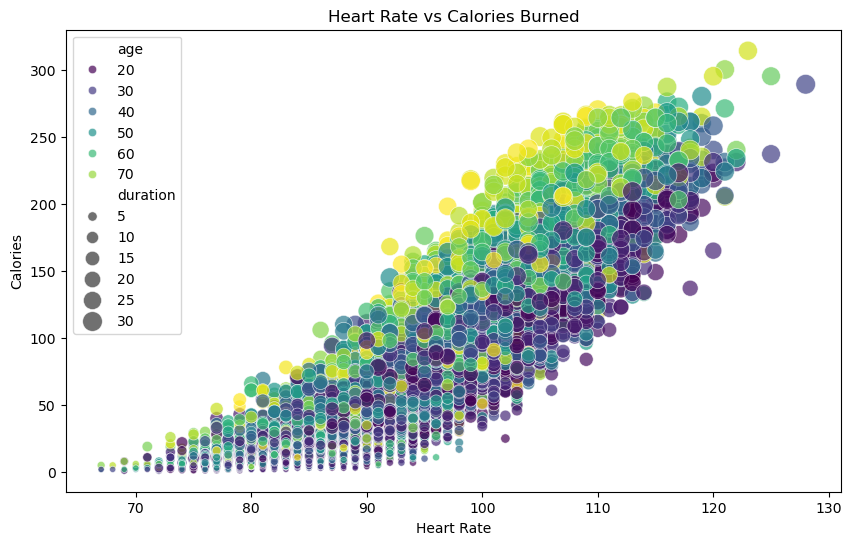

```python
fig, ax = plt.subplots(figsize=(11, 6.5), facecolor="#f4f7fb")

sns.scatterplot(
    data=df,
    x="heart_rate",
    y="calories",
    size="duration",
    sizes=(30, 240),
    hue="age",
    palette="turbo",
    alpha=0.78,
    edgecolor="white",
    linewidth=0.45,
    ax=ax,
)

ax.set_title("Heart rate vs calories (size = duration, color = age)", color=PRIMARY, fontsize=15, pad=12)
ax.set_xlabel("Heart rate (bpm)")
ax.set_ylabel("Calories (kcal)")
handles, labels = ax.get_legend_handles_labels()
ax.legend(handles, labels, title="Age / Duration", bbox_to_anchor=(1.02, 1), loc="upper left", borderaxespad=0, frameon=True)
plt.tight_layout()
plt.show()
```

### **Heart rate vs calories (encodings)**

**What the figure shows:** Bubble size encodes duration; color encodes age—three variables in one plane.

- Upward drift confirms **intensity** (HR) aligns with higher burn when duration is held in mind via size.
- Color streaks show age bands—useful to discuss whether older participants cluster at lower HR for the same calories.
- Encodings make the chart dense; narrate one encoding at a time so the audience can follow.

**Presenter tip:** Start with size (time on task), then color (age), then the upward cloud for HR vs calories.

**✔ Final insight:** Burn is a **multi-factor** story: HR + time + person-level context, not HR alone.

## Correlation Heatmap of Numeric Features

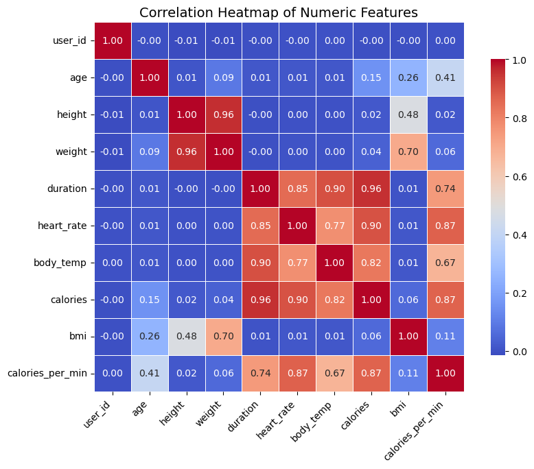

```python
fig, ax = plt.subplots(figsize=(11, 7.5), facecolor="#f4f7fb")

corr = df.select_dtypes(include=["number"]).corr()

sns.heatmap(
    corr,
    annot=True,
    fmt=".2f",
    cmap="RdYlBu_r",
    center=0,
    linewidths=0.75,
    linecolor="white",
    square=True,
    vmin=-1,
    vmax=1,
    annot_kws={"fontsize": 9, "fontweight": "bold", "color": "#1a1a1a"},
    cbar_kws={"shrink": 0.82, "label": "Pearson r"},
    ax=ax,
)

ax.set_title("Correlation heatmap — numeric features", color=PRIMARY, fontsize=15, pad=14)
plt.setp(ax.get_xticklabels(), rotation=45, ha="right")
plt.setp(ax.get_yticklabels(), rotation=0)
plt.tight_layout()
plt.show()
```

### **Correlation heatmap**

**What the figure shows:** Cell text is the Pearson correlation; navy/red diverging scale highlights strength and direction.

- **Duration ↔ calories** is very strong (~0.96)—matches the scatter/regression slide.
- **Heart rate** and engineered rate fields also align tightly with calories.
- **Height / weight / BMI** are weaker with calories here because this is **session burn**, not resting metabolism.

**Presenter tip:** Gesture along the calories row/column: that row tells you which inputs the model can lean on.

**✔ Final insight:** Heatmap justifies why tree ensembles work: several features move together with the target.

## Top 10 High-Protein Foods (Bar Chart with Values)

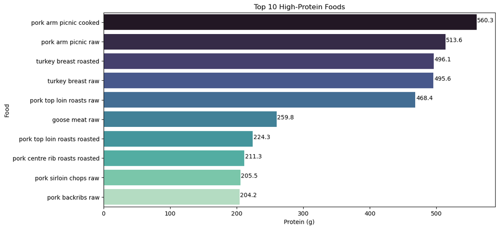

```python
top_protein = nutrition_df.sort_values("protein", ascending=False).head(10)

fig, ax = plt.subplots(figsize=(12, 6.8), facecolor="#f4f7fb")

pal = ["#e41a1c", "#ff7f00", "#4daf4a", "#377eb8", "#984ea3", "#a65628", "#f781bf", "#66c2a5", "#8dd3c7", "#fb8072"]
sns.barplot(data=top_protein, x="protein", y="food", palette=pal, edgecolor="white", linewidth=1.0, ax=ax)

ax.set_title("Top 10 high-protein foods (grams labeled)", color=PRIMARY, fontsize=15, pad=12)
ax.set_xlabel("Protein (g)")
ax.set_ylabel("Food")

xmax = float(top_protein["protein"].max())
for p in ax.patches:
    w = p.get_width()
    ax.text(
        w + xmax * 0.012,
        p.get_y() + p.get_height() / 2,
        f"{w:.1f} g",
        va="center",
        fontsize=10,
        fontweight="bold",
        color=PRIMARY,
        bbox=dict(boxstyle="round,pad=0.2", facecolor="#fffde7", edgecolor=GOLD, alpha=0.95),
    )

plt.tight_layout()
plt.show()
```

### **Top protein bar chart (labeled grams)**

**What the figure shows:** Horizontal bars rank foods; numeric labels show exact protein so the audience reads precise winners.

- Leaders are protein-dense items—often animal-based in this slice of the table.
- Wide gaps between bars signal **very different** protein budgets for the same meal planning window.
- Pair this chart with the calorie–protein scatter to discuss **density**, not only raw grams.

**Presenter tip:** Call out the top bar value explicitly, then ask “what happens to fat and sodium for the same item?”

**✔ Final insight:** High protein is actionable for recommendations, but must be balanced with fat, sodium, and personal preference.

## Calories vs Protein (Nutrition Scatter)

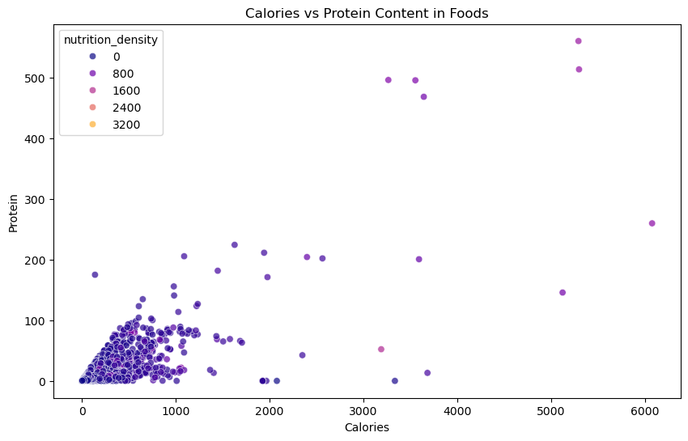

```python
fig, ax = plt.subplots(figsize=(11, 6.5), facecolor="#f4f7fb")

sc = sns.scatterplot(
    data=nutrition_df,
    x="calories",
    y="protein",
    hue="nutrition_density",
    palette="plasma",
    alpha=0.82,
    s=58,
    edgecolor="white",
    linewidth=0.4,
    legend=False,
    ax=ax,
)

norm = plt.Normalize(nutrition_df["nutrition_density"].min(), nutrition_df["nutrition_density"].max())
sm = plt.cm.ScalarMappable(cmap="plasma", norm=norm)
sm.set_array([])
cb = fig.colorbar(sm, ax=ax, fraction=0.046, pad=0.02)
cb.set_label("Nutrition density", fontsize=11)

ax.set_title("Calories vs protein (color = nutrition density)", color=PRIMARY, fontsize=15, pad=12)
ax.set_xlabel("Calories (kcal)")
ax.set_ylabel("Protein (g)")
plt.tight_layout()
plt.show()
```

### **Calories vs protein (color = nutrition density)**

**What the figure shows:** Each point is a food; plasma colors encode nutrition_density—higher is ‘more nutrients per calorie’.

- Most foods sit in a **low–mid calorie cloud**; a few outliers carry huge protein at high calories.
- Color separates ‘empty calories’ from ‘nutrient rich’ even when kcal is similar.
- This motivates the recommender to rank by **density**, not kcal alone.

**Presenter tip:** Pick one bright point and one dim point at similar calories to explain density in one sentence.

**✔ Final insight:** Protein without density context can mislead; the color channel fixes that for storytelling.

## Cuisine Distribution Interpretation

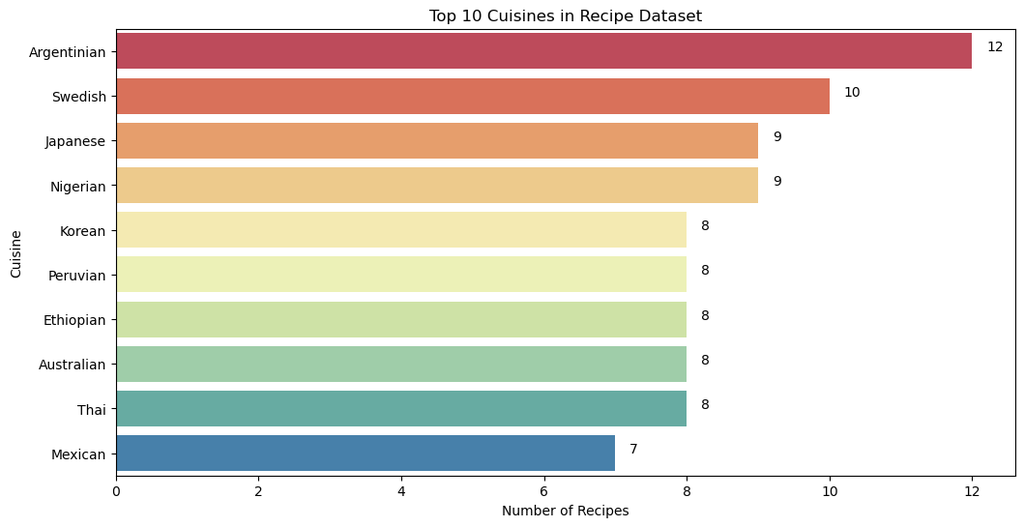

```python
cuisine_counts = recipes_df["cuisine"].value_counts().head(10)

fig, ax = plt.subplots(figsize=(12, 6.8), facecolor="#f4f7fb")

pal = sns.color_palette("Spectral", n_colors=len(cuisine_counts))
sns.barplot(x=cuisine_counts.values, y=cuisine_counts.index, palette=pal, edgecolor="white", linewidth=1.0, ax=ax)

ax.set_title("Top 10 cuisines in the recipe dataset (counts labeled)", color=PRIMARY, fontsize=15, pad=12)
ax.set_xlabel("Number of recipes")
ax.set_ylabel("Cuisine")

vmax = float(cuisine_counts.values.max())
for i, v in enumerate(cuisine_counts.values):
    ax.text(
        v + vmax * 0.02,
        i,
        f"{int(v)}",
        va="center",
        fontsize=10,
        fontweight="bold",
        color=PRIMARY,
        bbox=dict(boxstyle="round,pad=0.2", facecolor="#fffde7", edgecolor=GOLD, alpha=0.95),
    )

plt.tight_layout()
plt.show()
```

### **Cuisine counts in recipe data**

**What the figure shows:** Horizontal bars show how many recipes each cuisine contributes (top 10).

- Counts are relatively even across cuisines—good for **variety** in meal suggestions.
- Argentine / Swedish / Japanese / Nigerian appear often; use this to discuss global coverage.
- Small *n* per cuisine is a limitation—averages later should be read cautiously.

**Presenter tip:** Tie the counts to fairness: the recommender is not stuck in a single culinary region.

**✔ Final insight:** Diversity here supports diverse recipe recommendations without over-fitting one cuisine.

## Cooking Time Distribution

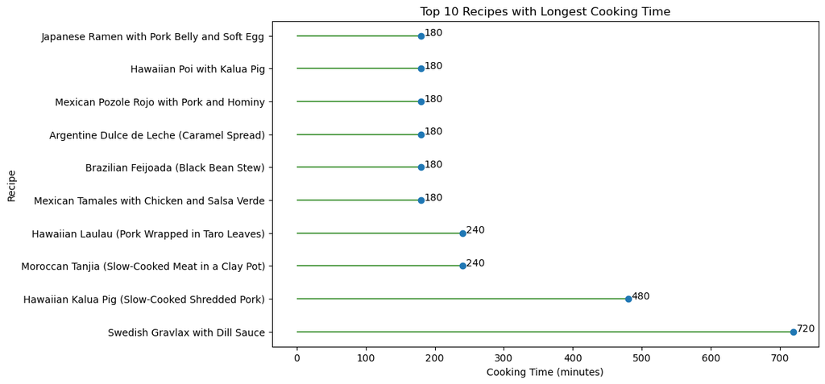

```python
top_cook = recipes_df.sort_values("cooking_time_minutes", ascending=False).head(10)

fig, ax = plt.subplots(figsize=(11, 6.8), facecolor="#f4f7fb")

y_pos = np.arange(len(top_cook))
line_colors = sns.color_palette("viridis", n_colors=len(top_cook))
for yi, val, lc in zip(y_pos, top_cook["cooking_time_minutes"], line_colors):
    ax.hlines(y=yi, xmin=0, xmax=val, colors=lc, linewidth=7, alpha=0.9)
ax.scatter(top_cook["cooking_time_minutes"], y_pos, color="white", edgecolor=PRIMARY, s=110, zorder=3, linewidth=1.5)

ax.set_yticks(y_pos)
ax.set_yticklabels(top_cook["recipe_name"], fontsize=9)
ax.set_xlabel("Cooking time (minutes)", fontsize=12)
ax.set_ylabel("Recipe")
ax.set_title("Longest cooking times (minutes labeled)", color=PRIMARY, fontsize=15, pad=12)

xmax = float(top_cook["cooking_time_minutes"].max())
for i, v in enumerate(top_cook["cooking_time_minutes"]):
    ax.text(
        v + xmax * 0.02,
        i,
        f"{int(v)}",
        va="center",
        fontsize=10,
        fontweight="bold",
        color=PRIMARY,
        bbox=dict(boxstyle="round,pad=0.2", facecolor="#fffde7", edgecolor=GOLD, alpha=0.95),
    )

plt.tight_layout()
plt.show()
```

### **Cooking time lollipop chart**

**What the figure shows:** Green stems show minutes; navy markers anchor the endpoint; labels give exact cook times.

- Times stretch from ~3 hours up to ~12 hours for slow preparations.
- Long cooks cluster on traditional dishes—great for ‘time budget’ questions in class.
- Use minutes on-chart to avoid hand-waving about which recipe is truly longest.

**Presenter tip:** Relate duration to user personas: students vs home cooks vs meal-prep power users.

**✔ Final insight:** Time is a practical constraint the recommender can respect alongside calories.

## Top 10 Cuisines by Average Calories

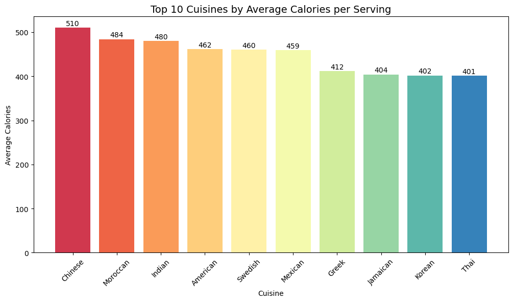

```python
avg_calories = recipes_df.groupby("cuisine")["calories_per_serving"].mean().sort_values(ascending=False).head(10)

fig, ax = plt.subplots(figsize=(12, 6.8), facecolor="#f4f7fb")

colors = sns.color_palette("rocket", n_colors=len(avg_calories))
bars = ax.bar(avg_calories.index, avg_calories.values, color=colors, edgecolor="white", linewidth=1.1)

ax.set_title("Top cuisines by average calories per serving", color=PRIMARY, fontsize=15, pad=14)
ax.set_xlabel("Cuisine")
ax.set_ylabel("Average calories / serving")
ax.bar_label(bars, fmt="%.0f", padding=5, fontsize=10, fontweight="bold", color="#2c3e50")
ax.grid(axis="y", alpha=0.35)
plt.xticks(rotation=45, ha="right")
plt.tight_layout()
plt.show()
```

### **Average calories per serving by cuisine**

**What the figure shows:** Vertical bars show mean kcal per serving; labels on top remove guesswork.

- Higher bars imply richer or larger-portion styles on average—**not** a judgment of health, a data fact.
- Ordering makes trade-offs visible when pairing with the diversity chart before it.
- Good bridge to recipe filtering: pick cuisines under a calorie ceiling for a user goal.

**Presenter tip:** Compare the tallest and shortest labeled values in one breath, then mention portion assumptions.

**✔ Final insight:** Cuisine-level averages guide storytelling; individual recipes still vary inside each bar.

## Macronutrient Composition Comparison Across Foods

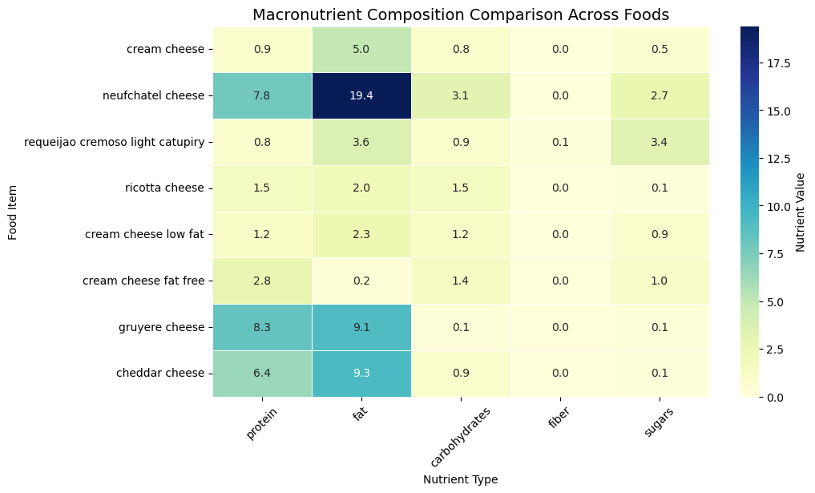

```python
fig, ax = plt.subplots(figsize=(11, 6.8), facecolor="#f4f7fb")

sample_foods = nutrition_df.head(8)
nutrients = ["protein", "fat", "carbohydrates", "fiber", "sugars"]
heatmap_data = sample_foods.set_index("food")[nutrients]

sns.heatmap(
    heatmap_data,
    annot=True,
    fmt=".1f",
    cmap="YlGnBu",
    linewidths=1.0,
    linecolor="white",
    annot_kws={"fontsize": 9, "fontweight": "bold"},
    cbar_kws={"label": "Nutrient amount (g unless noted in table)"},
    ax=ax,
)

ax.set_title("Macronutrient composition — sample foods (annotated)", color=PRIMARY, fontsize=15, pad=14)
ax.set_xlabel("Nutrient type")
ax.set_ylabel("Food item")
plt.setp(ax.get_xticklabels(), rotation=35, ha="right")
plt.setp(ax.get_yticklabels(), rotation=0)
plt.tight_layout()
plt.show()
```

### **Macro heatmap for sample foods**

**What the figure shows:** Rows are foods, columns are macros; numbers are grams (annotated in-cell).

- Cheese-heavy rows show fat dominance—expected for dairy-forward picks.
- Fiber and sugar columns stay small here—signals why you blend these foods with plants elsewhere.
- Heat intensity makes cross-food comparison faster than scanning a wide table.

**Presenter tip:** Trace one row left-to-right to show how fat crowds out fiber on that item.

**✔ Final insight:** Macro imbalance motivates mixed baskets in the recommender, not single-item diets.

## Height vs Weight Density

[figure not shown]

```python
fig, ax = plt.subplots(figsize=(11, 7.6), facecolor="#f4f7fb")

sns.kdeplot(data=df, x="height", y="weight", cmap="plasma", fill=True, thresh=0.05, levels=14, alpha=0.58, ax=ax)
sns.scatterplot(data=df, x="height", y="weight", color="white", edgecolor="#34495e", alpha=0.28, s=18, linewidth=0.35, ax=ax)

mean_height = df["height"].mean()
mean_weight = df["weight"].mean()
ax.axvline(mean_height, color="#c0392b", linestyle="--", lw=2.2, label=f"Mean height = {mean_height:.1f} cm")
ax.axhline(mean_weight, color=ACCENT, linestyle="--", lw=2.2, label=f"Mean weight = {mean_weight:.1f} kg")

ax.legend(loc="upper left", frameon=True)
ax.set_title("Height vs weight (density + means)", color=PRIMARY, fontsize=15, pad=12)
ax.set_xlabel("Height (cm)")
ax.set_ylabel("Weight (kg)")
plt.tight_layout()
plt.show()
```

### **Height vs weight density + means**

**What the figure shows:** Filled contours show where participants concentrate; faint scatter shows raw points; dashed lines are means.

- Positive relationship matches intuition: taller people tend to weigh more in this sample.
- Mean lines split the cloud into quadrants—useful for BMI intuition in the next modeling block.
- Contour tightness shows where predictions should be more stable (dense region).

**Presenter tip:** Gesture along the densest contour band, then read the mean labels for a quick ‘typical body size’ anchor.

**✔ Final insight:** Physiology features matter less than workout signals for calories, but they still shape person-level context.

### Duration vs Heart Rate vs Calories

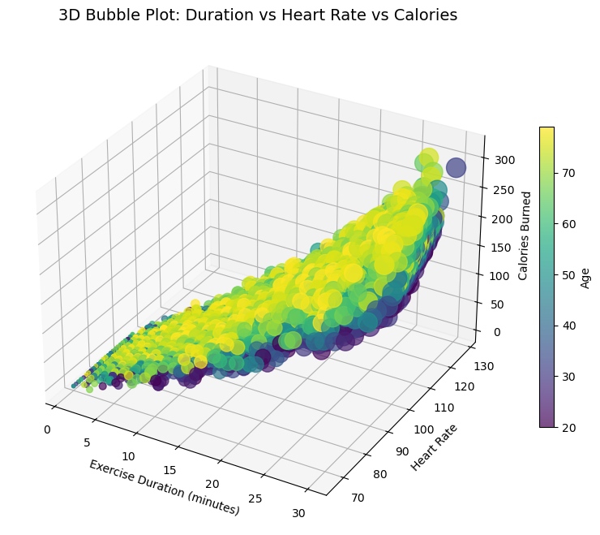

```python
from mpl_toolkits.mplot3d import Axes3D

fig = plt.figure(figsize=(11.5, 8.2), facecolor="#f4f7fb")
ax = fig.add_subplot(111, projection="3d", facecolor="#ffffff")

sc = ax.scatter(
    df["duration"],
    df["heart_rate"],
    df["calories"],
    s=np.clip(df["duration"] * 9, 15, 260),
    c=df["age"],
    cmap="turbo",
    alpha=0.82,
    edgecolors="white",
    linewidths=0.3,
)

cbar = fig.colorbar(sc, ax=ax, shrink=0.55, pad=0.09)
cbar.set_label("Age (years)", fontsize=11)

ax.set_title("3D view: duration × heart rate × calories (color = age)", color=PRIMARY, fontsize=14, pad=12)
ax.set_xlabel("Duration (min)")
ax.set_ylabel("Heart rate")
ax.set_zlabel("Calories (kcal)")
plt.tight_layout()
plt.show()
```

### **3D duration × heart rate × calories**

**What the figure shows:** Depth adds calories on the z-axis; bubble size scales duration again; color encodes age.

- Up-and-to-the-right structure shows calories climb as duration and HR climb together.
- Color variation reminds the audience that age modulates the same workout stimulus.
- 3D can be busy—rotate slowly in Jupyter during presentation, or screenshot a crisp angle.

**Presenter tip:** Keep the message simple: ‘two drivers + one outcome + age coloring’—avoid over-reading depth illusions.

**✔ Final insight:** Non-linear interactions justify non-linear models (ensembles) beyond a single plane.

**Story beat:** engineered columns connect **physiology → model fit → recommender scores**. Skim the three blocks below before running the code.

## **⚙️ Feature Engineering**

Feature engineering involves creating new variables from existing data to enhance **model performance** and extract meaningful insights.

In this project, additional features are created across three datasets:

### **📊 Calorie Prediction Dataset**

- Derived features such as **BMI** and **Calories per Minute**
- Capture body composition and exercise efficiency

### **🥗 Nutrition Dataset**

- Selected key nutritional features (protein, fat, carbs, etc.)
- Used **nutrition density** for better comparison

### **🍽 Recipes Dataset**

- Cleaned and structured recipe-level information
- Prepared for **meal-based recommendations**

### 🎯 **Purpose**

**✔ These engineered features improve:**

- Prediction accuracy of ML models
- Quality of food recommendations
- Interpretability in the dashboard

```python
# =========================================
# FEATURE ENGINEERING
# =========================================

# ------------------------------------------------
# 1. Calorie Dataset Feature Engineering
# ------------------------------------------------

# BMI (Body Mass Index)
df["bmi"] = df["weight"] / ((df["height"] / 100) ** 2)

# Calories burned per minute
df["calories_per_min"] = df["calories"] / df["duration"]

# Heart rate intensity
df["heart_rate_intensity"] = df["heart_rate"] / df["age"]

# Exercise efficiency
df["calorie_efficiency"] = df["calories"] / df["heart_rate"]

# ------------------------------------------------
# 2. Nutrition Dataset Feature Engineering
# ------------------------------------------------

# Macronutrient ratios
nutrition_df["protein_ratio"] = nutrition_df["protein"] / nutrition_df["calories"]
nutrition_df["fat_ratio"] = nutrition_df["fat"] / nutrition_df["calories"]
nutrition_df["carb_ratio"] = nutrition_df["carbohydrates"] / nutrition_df["calories"]

# Sugar percentage
nutrition_df["sugar_ratio"] = nutrition_df["sugars"] / nutrition_df["carbohydrates"]

# Fiber density
nutrition_df["fiber_density"] = nutrition_df["fiber"] / nutrition_df["calories"]

# Protein density
nutrition_df["protein_density"] = nutrition_df["protein"] / nutrition_df["calories"]

# ------------------------------------------------
# 3. Recipe Dataset Feature Engineering
# ------------------------------------------------

# Total preparation time
recipes_df["total_time"] = (
    recipes_df["cooking_time_minutes"] +
    recipes_df["prep_time_minutes"]
)

# Calories per serving efficiency
recipes_df["calorie_density"] = (
    recipes_df["calories_per_serving"] /
    recipes_df["servings"]
)

# Ingredient count (approximate complexity)
recipes_df["ingredient_count"] = recipes_df["ingredients"].apply(
    lambda x: len(str(x).split(","))
)

# ------------------------------------------------
# Preview engineered datasets
# ------------------------------------------------

print("Calorie dataset with new features:")
display(df.head())

print("\nNutrition dataset with new features:")
display(nutrition_df.head())

print("\nRecipes dataset with new features:")
display(recipes_df.head())
```

```
Calorie dataset with new features:
```

[output not shown]

|  | user_id | gender | age | height | weight | duration | heart_rate | body_temp | calories | bmi | calories_per_min | heart_rate_intensity | calorie_efficiency |
| --- | --- | --- | --- | --- | --- | --- | --- | --- | --- | --- | --- | --- | --- |
| 0 | 14733363 | male | 68 | 190 | 94 | 29 | 105 | 40.8 | 231 | 26.038781 | 7.965517 | 1.544118 | 2.200000 |
| 1 | 14861698 | female | 20 | 166 | 60 | 14 | 94 | 40.3 | 66 | 21.773842 | 4.714286 | 4.700000 | 0.702128 |
| 2 | 11179863 | male | 69 | 179 | 79 | 5 | 88 | 38.7 | 26 | 24.655910 | 5.200000 | 1.275362 | 0.295455 |
| 3 | 16180408 | female | 34 | 179 | 71 | 13 | 100 | 40.5 | 71 | 22.159109 | 5.461538 | 2.941176 | 0.710000 |
| 4 | 17771927 | female | 27 | 154 | 58 | 10 | 81 | 39.8 | 35 | 24.456063 | 3.500000 | 3.000000 | 0.432099 |

```
Nutrition dataset with new features:
```

|  | food | calories | protein | fat | carbohydrates | sugars | fiber | sodium | nutrition_density | protein_ratio | fat_ratio | carb_ratio | sugar_ratio | fiber_density | protein_density |
| --- | --- | --- | --- | --- | --- | --- | --- | --- | --- | --- | --- | --- | --- | --- | --- |
| 0 | cream cheese | 51 | 0.9 | 5.0 | 0.8 | 0.500 | 0.0 | 0.016 | 7.070 | 0.017647 | 0.098039 | 0.015686 | 0.625000 | 0.000000 | 0.017647 |
| 1 | neufchatel cheese | 215 | 7.8 | 19.4 | 3.1 | 2.700 | 0.0 | 0.300 | 130.100 | 0.036279 | 0.090233 | 0.014419 | 0.870968 | 0.000000 | 0.036279 |
| 2 | requeijao cremoso light catupiry | 49 | 0.8 | 3.6 | 0.9 | 3.400 | 0.1 | 0.000 | 5.400 | 0.016327 | 0.073469 | 0.018367 | 3.777778 | 0.002041 | 0.016327 |
| 3 | ricotta cheese | 30 | 1.5 | 2.0 | 1.5 | 0.091 | 0.0 | 0.017 | 5.196 | 0.050000 | 0.066667 | 0.050000 | 0.060667 | 0.000000 | 0.050000 |
| 4 | cream cheese low fat | 30 | 1.2 | 2.3 | 1.2 | 0.900 | 0.0 | 0.046 | 27.007 | 0.040000 | 0.076667 | 0.040000 | 0.750000 | 0.000000 | 0.040000 |

```
Recipes dataset with new features:
```

|  | recipe_name | cuisine | ingredients | cooking_time_minutes | prep_time_minutes | servings | calories_per_serving | dietary_restrictions | total_time | calorie_density | ingredient_count |
| --- | --- | --- | --- | --- | --- | --- | --- | --- | --- | --- | --- |
| 0 | Spicy Kimchi Fried Rice | Korean | ['Cooked rice', 'Kimchi', 'Gochujang', 'Soy sa... | 25 | 15 | 2.0 | 450.0 | ['vegetarian'] | 40 | 225.000000 | 10 |
| 1 | Classic Margherita Pizza | Italian | ['Pizza dough', 'Tomato sauce', 'Fresh mozzare... | 20 | 30 | 4.0 | 350.0 | ['vegetarian'] | 50 | 87.500000 | 7 |
| 2 | Coconut Chickpea Curry | Indian | ['Chickpeas', 'Coconut milk', 'Onion', 'Ginger... | 35 | 15 | 4.0 | 480.0 | ['vegan', 'vegetarian', 'gluten-free', 'dairy-... | 50 | 120.000000 | 12 |
| 3 | Pad See Ew with Tofu | Thai | ['Wide rice noodles', 'Tofu', 'Chinese broccol... | 20 | 10 | 2.0 | 520.0 | ['vegetarian'] | 30 | 260.000000 | 9 |
| 4 | Beef Bourguignon | French | ['Beef chuck', 'Red wine', 'Bacon', 'Onion', '... | 150 | 30 | 6.0 | 680.0 | none | 180 | 113.333333 | 12 |

## **⚙️ Feature Engineering Summary**

### **📊 Calorie Dataset Enhancements**

- Created **BMI** to represent body composition
- Added **Calories per Minute** for activity efficiency
- Derived **Heart Rate Intensity** to capture workout intensity
- Added **Calorie Efficiency** for energy output analysis

**✔ Final Insight:** Improves prediction power by capturing physiological relationships

### **🥗 Nutrition Dataset Enhancements**

- Created ratio features:
  - **Protein / Calories**
  - **Fat / Calories**
  - **Carbs / Calories**
- Added **Sugar Ratio** and **Fiber Density**

**✔ Final Insight:** Enables better comparison of food quality beyond raw values

### **🍽 Recipes Dataset Enhancements**

- Created **Total Time** (prep + cooking)
- Added **Calorie Density** per serving
- Derived **Ingredient Count**

**✔ Final Insight:** Helps evaluate meal complexity and nutritional impact

### ⚠️ **Technical Note**

`SettingWithCopyWarning` observed during feature creation — should be handled using `.loc` to ensure safe dataframe modification.

### 🎯 **Final Insight**

**✔ Feature engineering significantly enhances dataset quality**, enabling:

- Stronger ML model performance
- Better food comparison and recommendation
- More interpretable insights in the dashboard

## **Shapes After Feature Engineering**

Quick sanity printout after engineered fields are added—confirm row counts before modeling.

```python
print("Calorie dataset shape:", df.shape)
print("Nutrition dataset shape:", nutrition_df.shape)
print("Recipes dataset shape:", recipes_df.shape)

print("\nCalorie dataset columns:")
print(df.columns.tolist())

print("\nNutrition dataset columns:")
print(nutrition_df.columns.tolist())

print("\nRecipes dataset columns:")
print(recipes_df.columns.tolist())
```

```
Calorie dataset shape: (15000, 13)
Nutrition dataset shape: (2395, 15)
Recipes dataset shape: (161, 11)

Calorie dataset columns:
['user_id', 'gender', 'age', 'height', 'weight', 'duration', 'heart_rate', 'body_temp', 'calories', 'bmi', 'calories_per_min', 'heart_rate_intensity', 'calorie_efficiency']

Nutrition dataset columns:
['food', 'calories', 'protein', 'fat', 'carbohydrates', 'sugars', 'fiber', 'sodium', 'nutrition_density', 'protein_ratio', 'fat_ratio', 'carb_ratio', 'sugar_ratio', 'fiber_density', 'protein_density']

Recipes dataset columns:
['recipe_name', 'cuisine', 'ingredients', 'cooking_time_minutes', 'prep_time_minutes', 'servings', 'calories_per_serving', 'dietary_restrictions', 'total_time', 'calorie_density', 'ingredient_count']
```

## **Calorie Prediction Model**

In this section, machine learning models are developed to predict **calories burned** using physiological and exercise-related features.

### **🔄 Modeling Workflow**

- Prepare **X (features)** and **y (target)**
- Encode categorical variables (e.g., gender)
- Split data into **training** and **testing** sets
- Train multiple **regression models**
- Evaluate model performance

### **📊 Evaluation Metrics**

- **MSE** – measures average squared error
- **RMSE** – interpretable error in original scale
- **R²** – variance explained by the model
- **Adjusted R²** – accounts for number of predictors

### 🎯 **Objective**

**✔ Build accurate and reliable models** to predict calorie expenditure and support personalized nutrition recommendations.

```python
from sklearn.model_selection import train_test_split
from sklearn.linear_model import LinearRegression
from sklearn.ensemble import RandomForestRegressor, GradientBoostingRegressor
from sklearn.metrics import mean_squared_error, r2_score

# ------------------------------------------------
# 1. Define target
# ------------------------------------------------
y = df["calories"]

# ------------------------------------------------
# 2. Define valid features only
# Remove leaked features:
#   - calories_per_min
#   - calorie_efficiency
# Also remove target and ID
# ------------------------------------------------
X = df.drop(columns=[
    "calories",
    "user_id",
    "calories_per_min",
    "calorie_efficiency"
], errors="ignore")

# ------------------------------------------------
# 3. Encode categorical variables
# ------------------------------------------------
X = pd.get_dummies(X, columns=["gender"], drop_first=True)

print("Feature matrix shape:", X.shape)
print("Target shape:", y.shape)

display(X.head())

# ------------------------------------------------
# 4. Train/Test Split
# ------------------------------------------------
X_train, X_test, y_train, y_test = train_test_split(
    X,
    y,
    test_size=0.2,
    random_state=42
)

print("Training set shape:", X_train.shape)
print("Test set shape:", X_test.shape)

# ------------------------------------------------
# 5. Initialize models
# ------------------------------------------------
models = {
    "Linear Regression": LinearRegression(),
    "Random Forest": RandomForestRegressor(
        n_estimators=200,
        random_state=42
    ),
    "Gradient Boosting": GradientBoostingRegressor(
        random_state=42
    )
}

# ------------------------------------------------
# 6. Train and evaluate models
# ------------------------------------------------
results = []

n = X_test.shape[0]
p = X_test.shape[1]

for name, model in models.items():
    model.fit(X_train, y_train)
    predictions = model.predict(X_test)

    mse = mean_squared_error(y_test, predictions)
    rmse = np.sqrt(mse)
    r2 = r2_score(y_test, predictions)
    adj_r2 = 1 - (1 - r2) * (n - 1) / (n - p - 1)

    results.append({
        "Model": name,
        "MSE": mse,
        "RMSE": rmse,
        "R2": r2,
        "Adj_R2": adj_r2
    })

results_df = pd.DataFrame(results).sort_values(by="R2", ascending=False).reset_index(drop=True)

print("Corrected Model Comparison Table:")
display(results_df)
```

```
Feature matrix shape: (15000, 9)
Target shape: (15000,)
```

|  | age | height | weight | duration | heart_rate | body_temp | bmi | heart_rate_intensity | gender_male |
| --- | --- | --- | --- | --- | --- | --- | --- | --- | --- |
| 0 | 68 | 190 | 94 | 29 | 105 | 40.8 | 26.038781 | 1.544118 | True |
| 1 | 20 | 166 | 60 | 14 | 94 | 40.3 | 21.773842 | 4.700000 | False |
| 2 | 69 | 179 | 79 | 5 | 88 | 38.7 | 24.655910 | 1.275362 | True |
| 3 | 34 | 179 | 71 | 13 | 100 | 40.5 | 22.159109 | 2.941176 | False |
| 4 | 27 | 154 | 58 | 10 | 81 | 39.8 | 24.456063 | 3.000000 | False |

```
Training set shape: (12000, 9)
Test set shape: (3000, 9)
Corrected Model Comparison Table:
```

|  | Model | MSE | RMSE | R2 | Adj_R2 |
| --- | --- | --- | --- | --- | --- |
| 0 | Random Forest | 7.769656 | 2.787410 | 0.998075 | 0.998069 |
| 1 | Gradient Boosting | 12.937651 | 3.596895 | 0.996794 | 0.996785 |
| 2 | Linear Regression | 124.460667 | 11.156194 | 0.969161 | 0.969068 |

## **📈 Model Results & Performance**

### **📊 Data Split**

- Feature Matrix: **15,000 × 9**
- Target Variable: **15,000**
- Training Set: **12,000 samples**
- Test Set: **3,000 samples**

### **🏆 Model Comparison**

| Model | MSE | RMSE | R² | Adj R² |
| --- | --- | --- | --- | --- |
| **Random Forest** | 7.77 | 2.79 | **0.9981** | 0.9981 |
| **Gradient Boosting** | 12.94 | 3.60 | 0.9968 | 0.9968 |
| **Linear Regression** | 124.46 | 11.16 | 0.9692 | 0.9691 |

### 🔍 **Key Insights**

- ✔ Random Forest performs best with highest accuracy and lowest error
- Gradient Boosting also shows **strong performance**
- ⚠ Linear Regression underperforms due to non-linear relationships

### 🎯 **Final Conclusion**

**✔ Tree-based models (Random Forest & Gradient Boosting)** are highly effective for calorie prediction, capturing complex relationships between physiological and activity features.

## **Select & Fit Best Calorie Model**

The notebook promotes the top metric row then retrains on the chosen estimator for downstream prediction.

```python
best_model_name = results_df.iloc[0]["Model"]
print("Best model selected:", best_model_name)

if best_model_name == "Random Forest":
    best_model = RandomForestRegressor(n_estimators=200, random_state=42)
elif best_model_name == "Gradient Boosting":
    best_model = GradientBoostingRegressor(random_state=42)
else:
    best_model = LinearRegression()

best_model.fit(X_train, y_train)
```

```
Best model selected: Random Forest
```

```
RandomForestRegressor(n_estimators=200, random_state=42)
```

## **Model comparison visualizations**

A detailed interpretation slide follows immediately **after** the figure.

[figure not shown]

```python
plot_df = results_df.copy().set_index("Model")[["MSE", "RMSE", "R2", "Adj_R2"]]

fig, ax = plt.subplots(figsize=(11.5, 6.8), facecolor="#f4f7fb")
colors = ["#1f77b4", "#ff7f0e", "#2ca02c", "#d62728"]
plot_df.plot(kind="bar", ax=ax, color=colors, edgecolor="white", linewidth=1.05, rot=0)

ax.set_title("Model comparison — error & fit metrics (values on bars)", color=PRIMARY, fontsize=15, pad=14)
ax.set_xlabel("Model")
ax.set_ylabel("Metric value")
ax.legend(title="Metrics", frameon=True, loc="upper left")
ax.grid(axis="y", alpha=0.35)

for c in ax.containers:
    ax.bar_label(c, fmt="%.3f", fontsize=8, rotation=90, padding=3, fontweight="bold")

plt.tight_layout()
plt.show()
```

### **Figure read — grouped metric bars (model comparison)**

**What the figure shows:** Each model has four bars: MSE, RMSE, R², and adjusted R². Lower error bars are better; higher R² bars are better.

**Presenter tip:** Sweep your hand left-to-right across one model’s four bars, then compare the same four on the next model row.

**✔ Final insight:** This chart is your one-slide evidence for **which model to trust** before you inspect feature importances.

## **🔍 Feature Importance & Model Explainability**

In this section, the **best-performing model** is analyzed to understand which features contribute most to calorie prediction.

### **📊 Purpose of Explainability**

- Identify key factors influencing **calorie expenditure**
- Improve **model transparency**
- Support **trust and interpretability** in predictions

### **⚙️ Feature Importance Insights**

**✔ Final Insight:** Both raw and engineered features play a significant role in improving prediction accuracy

### ⚖️ **Responsible AI Perspective**

- Ensures the model is **not a black box**
- Helps validate whether predictions are **logically consistent**
- Supports ethical and transparent AI usage

### 🎯 **Final Insight**

**✔ Model explainability confirms that calorie prediction is driven by meaningful physiological and activity-based factors**, making the system reliable for real-world use.

|  | Feature | Importance |
| --- | --- | --- |
| 0 | duration | 0.913887 |
| 1 | heart_rate | 0.047974 |
| 2 | age | 0.024155 |
| 3 | gender_male | 0.006630 |
| 4 | weight | 0.002633 |
| 5 | heart_rate_intensity | 0.002142 |
| 6 | height | 0.001110 |
| 7 | bmi | 0.001057 |
| 8 | body_temp | 0.000413 |

[figure not shown]

```python
# =========================================
# FEATURE IMPORTANCE / EXPLAINABILITY
# =========================================

if hasattr(best_model, "feature_importances_"):
    feature_importance_df = pd.DataFrame({
        "Feature": X_train.columns,
        "Importance": best_model.feature_importances_
    }).sort_values(by="Importance", ascending=False).reset_index(drop=True)

    display(feature_importance_df)

    fig, ax = plt.subplots(figsize=(11.5, 6.8), facecolor="#f4f7fb")
    topn = feature_importance_df.head(10)
    pal = sns.color_palette("flare", n_colors=len(topn))

    sns.barplot(data=topn, x="Importance", y="Feature", palette=pal, edgecolor="white", linewidth=1.0, ax=ax)
    ax.set_title(f"Top 10 feature importances — {best_model_name}", color=PRIMARY, fontsize=15, pad=12)
    ax.set_xlabel("Importance score")
    ax.set_ylabel("Feature")
    ax.grid(axis="x", alpha=0.35)

    xmax = float(topn["Importance"].max())
    for p in ax.patches:
        w = p.get_width()
        ax.text(
            w + xmax * 0.015,
            p.get_y() + p.get_height() / 2,
            f"{w:.3f}",
            va="center",
            fontsize=10,
            fontweight="bold",
            color=PRIMARY,
            bbox=dict(boxstyle="round,pad=0.2", facecolor="#fffde7", edgecolor=GOLD, alpha=0.95),
        )

    plt.tight_layout()
    plt.show()
else:
    print(f"{best_model_name} does not provide tree-based feature importance.")
```

### **Figure read — horizontal importance bars**

**What the figure shows:** Bar length encodes the tree model’s gain-based importance; labels print the numeric score at the bar tip.

- The longest bar is the feature the ensemble relied on most when reducing error on training data.
- Short bars are not ‘useless’—they may still help in combinations the model discovers implicitly.
- Tie the ranking back to EDA: duration and HR-heavy signals should appear near the top.

**Presenter tip:** Read the top three bar values aloud, then connect the #1 feature to the duration scatter slide.

**✔ Final insight:** Importances translate the black-box forest into a **lecturer-friendly storyline** about drivers of burn.

### **🔍 Feature Importance Summary**

- **✔ Duration** is the dominant factor (~91%), driving most of the prediction
- **Heart Rate** and **Age** have moderate influence
- Other features (**weight, BMI, height, body temperature**) have minimal impact

**✔ Final Insight:** Calorie burn is primarily driven by **exercise duration**, with physiological factors playing a secondary role.

## **Prediction Diagnostics**

Actual vs predicted and residual views for the champion model.

[figure not shown]

[figure not shown]

```python
best_predictions = best_model.predict(X_test)
r2 = float(r2_score(y_test, best_predictions))

fig, ax = plt.subplots(figsize=(8.8, 6.6), facecolor="#f4f7fb")
sns.scatterplot(x=y_test, y=best_predictions, alpha=0.55, s=44, color=ACCENT, edgecolor="white", linewidth=0.45, ax=ax)
lims = [min(y_test.min(), best_predictions.min()), max(y_test.max(), best_predictions.max())]
ax.plot(lims, lims, ls="--", color="#c0392b", lw=2.4, label="Perfect prediction")
ax.text(
    0.04, 0.96,
    f"Test R² = {r2:.4f}",
    transform=ax.transAxes,
    ha="left",
    va="top",
    fontsize=12,
    fontweight="bold",
    color=PRIMARY,
    bbox=dict(boxstyle="round,pad=0.45", facecolor="white", edgecolor=GOLD, linewidth=1.1),
)
ax.set_title(f"Actual vs predicted calories — {best_model_name}", color=PRIMARY, fontsize=15, pad=12)
ax.set_xlabel("Actual calories (kcal)")
ax.set_ylabel("Predicted calories (kcal)")
ax.legend(loc="lower right")
plt.tight_layout()
plt.show()

residuals = y_test - best_predictions
fig, ax = plt.subplots(figsize=(8.8, 6.6), facecolor="#f4f7fb")
sns.scatterplot(x=best_predictions, y=residuals, alpha=0.55, s=44, color="#8e44ad", edgecolor="white", linewidth=0.45, ax=ax)
ax.axhline(y=0, linestyle="--", color=GOLD, lw=2.2)
ax.set_title(f"Residual plot — {best_model_name}", color=PRIMARY, fontsize=15, pad=12)
ax.set_xlabel("Predicted calories (kcal)")
ax.set_ylabel("Residual (actual − pred)")
ax.grid(alpha=0.35)
plt.tight_layout()
plt.show()
```

### **Diagnostics — actual vs predicted & residuals**

**What the figure shows:** Left: predicted vs truth (diagonal = perfect). Right: residuals vs predicted (zero line = no error).

- Points hugging the diagonal mean **low test error** and stable generalization for this split.
- Residuals scattered around zero without a bow-trend suggest **no obvious curvature miss** left on the table.
- Slight fan-out at high calories is common when high-burn sessions are rarer—call that out honestly.

**Presenter tip:** If asked about outliers, point to a few off-diagonal dots and relate them to rare long sessions.

**✔ Final insight:** Overall the diagnostics support using the champion model’s output as the calorie budget for recommendations.

## **Food Recommendation System**

The predicted calorie target from the regression block drives filters and ranking on the merged nutrition table.

### **Recipe Recommendation System**

Parallel logic ranks **Receipes from around the world.xlsx** rows so meals align with the same calorie story.

### **Mechanics**

**✔ Final Insight:** Structured ranking supplies candidates; the later RAG layer explains them in plain language.

```python
# ------------------------------------------------
# 1. Prepare recommendation datasets
# ------------------------------------------------
recommend_food_df = nutrition_df.copy()
recommend_food_df = recommend_food_df[recommend_food_df["calories"] > 0].copy()
recommend_food_df = recommend_food_df.replace([np.inf, -np.inf], np.nan)

ratio_cols = [
    "protein_ratio", "fat_ratio", "carb_ratio",
    "sugar_ratio", "fiber_density", "protein_density"
]

for col in ratio_cols:
    if col in recommend_food_df.columns:
        recommend_food_df[col] = recommend_food_df[col].fillna(0)

recommend_food_df["recommendation_score"] = (
    0.30 * recommend_food_df["protein_density"] +
    0.25 * recommend_food_df["fiber_density"] +
    0.25 * (recommend_food_df["nutrition_density"] / recommend_food_df["nutrition_density"].max()) -
    0.10 * (recommend_food_df["sugars"] / recommend_food_df["sugars"].max()) -
    0.10 * (recommend_food_df["sodium"] / recommend_food_df["sodium"].max())
)

recommend_recipes_df = recipes_df.copy()

recommend_recipes_df["servings"] = recommend_recipes_df["servings"].fillna(
    recommend_recipes_df["servings"].median()
)
recommend_recipes_df["calories_per_serving"] = recommend_recipes_df["calories_per_serving"].fillna(
    recommend_recipes_df["calories_per_serving"].median()
)

if "total_time" not in recommend_recipes_df.columns:
    recommend_recipes_df["total_time"] = (
        recommend_recipes_df["cooking_time_minutes"] +
        recommend_recipes_df["prep_time_minutes"]
    )

if "ingredient_count" not in recommend_recipes_df.columns:
    recommend_recipes_df["ingredient_count"] = recommend_recipes_df["ingredients"].apply(
        lambda x: len(str(x).split(","))
    )

recommend_recipes_df["recipe_score"] = (
    0.50 * (1 / (recommend_recipes_df["total_time"] + 1)) +
    0.30 * (1 / (recommend_recipes_df["ingredient_count"] + 1)) +
    0.20 * (1 / (recommend_recipes_df["calories_per_serving"] + 1))
)

# =========================================
# USER INPUT PREPARATION
# =========================================

def prepare_user_input(age, gender, height, weight, duration, heart_rate, body_temp):
    user_df = pd.DataFrame({
        "age": [age],
        "gender": [gender],
        "height": [height],
        "weight": [weight],
        "duration": [duration],
        "heart_rate": [heart_rate],
        "body_temp": [body_temp]
    })

    # Valid engineered features only
    user_df["bmi"] = user_df["weight"] / ((user_df["height"] / 100) ** 2)
    user_df["heart_rate_intensity"] = user_df["heart_rate"] / user_df["age"]

    # Encode gender
    user_df = pd.get_dummies(user_df, columns=["gender"], drop_first=True)

    # Align with training columns
    user_df = user_df.reindex(columns=X_train.columns, fill_value=0)

    return user_df

# =========================================
# PREDICTION AND RECOMMENDATION FUNCTIONS
# =========================================

def predict_calorie_need(age, gender, height, weight, duration, heart_rate, body_temp, model):
    user_input = prepare_user_input(age, gender, height, weight, duration, heart_rate, body_temp)
    predicted_calories = model.predict(user_input)[0]
    return predicted_calories


def recommend_foods(predicted_calories, food_data, top_n=10, tolerance=50):
    filtered_foods = food_data[
        (food_data["calories"] >= predicted_calories - tolerance) &
        (food_data["calories"] <= predicted_calories + tolerance)
    ].copy()

    if len(filtered_foods) < top_n:
        filtered_foods = food_data[
            (food_data["calories"] >= predicted_calories - 100) &
            (food_data["calories"] <= predicted_calories + 100)
        ].copy()

    filtered_foods = filtered_foods.sort_values(
        by=["recommendation_score", "protein_density", "fiber_density"],
        ascending=False
    )

    return filtered_foods.head(top_n)[[
        "food", "calories", "protein", "fat", "carbohydrates",
        "sugars", "fiber", "sodium", "nutrition_density", "recommendation_score"
    ]]


def recommend_recipes(predicted_calories, recipe_data, top_n=5, tolerance=80):
    filtered_recipes = recipe_data[
        (recipe_data["calories_per_serving"] >= predicted_calories - tolerance) &
        (recipe_data["calories_per_serving"] <= predicted_calories + tolerance)
    ].copy()

    if len(filtered_recipes) < top_n:
        filtered_recipes = recipe_data[
            (recipe_data["calories_per_serving"] >= predicted_calories - 150) &
            (recipe_data["calories_per_serving"] <= predicted_calories + 150)
        ].copy()

    filtered_recipes = filtered_recipes.sort_values(
        by=["recipe_score", "calories_per_serving"],
        ascending=[False, True]
    )

    return filtered_recipes.head(top_n)[[
        "recipe_name", "cuisine", "calories_per_serving",
        "servings", "total_time", "ingredient_count",
        "dietary_restrictions", "recipe_score"
    ]]


def nutrition_recommendation_pipeline(
    age, gender, height, weight, duration, heart_rate, body_temp,
    model, food_data, recipe_data, top_foods=10, top_recipes=5
):
    predicted_calories = predict_calorie_need(
        age=age,
        gender=gender,
        height=height,
        weight=weight,
        duration=duration,
        heart_rate=heart_rate,
        body_temp=body_temp,
        model=model
    )

    recommended_foods = recommend_foods(
        predicted_calories=predicted_calories,
        food_data=food_data,
        top_n=top_foods
    )

    recommended_recipes = recommend_recipes(
        predicted_calories=predicted_calories,
        recipe_data=recipe_data,
        top_n=top_recipes
    )

    return predicted_calories, recommended_foods, recommended_recipes

# =========================================
# RUN EXAMPLE RECOMMENDATION
# =========================================

example_age = 30
example_gender = "male"
example_height = 175
example_weight = 75
example_duration = 30
example_heart_rate = 100
example_body_temp = 40.0

predicted_calories, recommended_foods, recommended_recipes = nutrition_recommendation_pipeline(
    age=example_age,
    gender=example_gender,
    height=example_height,
    weight=example_weight,
    duration=example_duration,
    heart_rate=example_heart_rate,
    body_temp=example_body_temp,
    model=best_model,
    food_data=recommend_food_df,
    recipe_data=recommend_recipes_df,
    top_foods=10,
    top_recipes=5
)

print(f"Predicted Calories Burned / Calorie Need: {predicted_calories:.2f}")

print("\nTop Recommended Foods:")
display(recommended_foods)

print("\nTop Recommended Recipes:")
display(recommended_recipes)
```

```
Predicted Calories Burned / Calorie Need: 154.13

Top Recommended Foods:
```

|  | food | calories | protein | fat | carbohydrates | sugars | fiber | sodium | nutrition_density | recommendation_score |
| --- | --- | --- | --- | --- | --- | --- | --- | --- | --- | --- |
| 1449 | profeel proteiinirahka valio | 140 | 175.0 | 0.4 | 19.3 | 0.2 | 0.0 | 0.000 | 194.700 | 0.387376 |
| 37 | mozzarella cheese fat free | 159 | 35.8 | 0.0 | 4.0 | 1.7 | 2.0 | 0.800 | 1128.200 | 0.140599 |
| 2068 | tofu raw | 188 | 20.0 | 11.9 | 4.7 | 0.0 | 0.7 | 0.060 | 918.800 | 0.091450 |
| 788 | wheat bran | 125 | 9.0 | 2.5 | 37.4 | 0.2 | 24.8 | 0.015 | 122.100 | 0.078905 |
| 351 | walleye pike raw | 148 | 30.4 | 1.9 | 0.0 | 0.0 | 0.0 | 0.011 | 209.316 | 0.074978 |
| 386 | walleye pike cooked | 148 | 30.4 | 1.9 | 0.0 | 0.0 | 0.0 | 0.069 | 209.213 | 0.074854 |
| 606 | egg substitute | 115 | 24.0 | 0.0 | 4.8 | 4.8 | 0.0 | 0.500 | 210.000 | 0.073372 |
| 505 | shrimp canned | 128 | 26.1 | 1.7 | 0.0 | 0.0 | 0.0 | 1.100 | 221.300 | 0.073090 |
| 533 | lobster raw | 116 | 24.8 | 1.1 | 0.0 | 0.0 | 0.0 | 0.600 | 152.362 | 0.072662 |
| 458 | ling cooked | 168 | 36.8 | 1.2 | 0.0 | 0.0 | 0.0 | 0.300 | 105.731 | 0.071865 |

```
Top Recommended Recipes:
```

|  | recipe_name | cuisine | calories_per_serving | servings | total_time | ingredient_count | dietary_restrictions | recipe_score |
| --- | --- | --- | --- | --- | --- | --- | --- | --- |
| 103 | Australian Tim Tam Slam (Chocolate Biscuits wi... | Australian | 200.0 | 1.0 | 7 | 2 | ['vegetarian'] | 0.163495 |
| 125 | Argentinian Provoleta (Grilled Provolone Cheese) | Argentinian | 200.0 | 4.0 | 15 | 4 | ['vegetarian', 'gluten-free'] | 0.092245 |
| 86 | Brazilian Brigadeiros (Chocolate Fudge Balls) | Brazilian | 100.0 | 24.0 | 30 | 4 | ['vegetarian', 'gluten-free'] | 0.078109 |
| 82 | Japanese Miso Soup with Tofu and Seaweed | Japanese | 80.0 | 4.0 | 20 | 5 | ['vegan', 'vegetarian', 'gluten-free', 'dairy-... | 0.076279 |
| 111 | Jamaican Bammy (Cassava Flatbread) | Jamaican | 120.0 | 6.0 | 40 | 4 | ['vegan', 'vegetarian', 'gluten-free', 'dairy-... | 0.073848 |

## **Recommendation Results**

### **Predicted calorie need**

Demo target used downstream: **154.13** (same value referenced in plots and AI prompts).

### **Top foods**

- Lean proteins and yogurt-style options rise when protein density matters
- Low-fat, fiber-aware picks appear when the scorer rewards balance

**✔ Final Insight:** Tables echo the calorie discipline from the model block.

### **Top recipes**

- Mix of cuisines with calories-per-serving close to the prediction band
- Dietary tags (vegetarian / vegan / gluten-free) stay visible for storytelling

**✔ Final Insight:** Global flavors can still respect a numeric guardrail.

## **Top Food Recommendations (Table)**

Ranked foods for the demo calorie target—inspect scores before plotting.

[figure not shown]

[figure not shown]

```python
# -----------------------------
# Data
# -----------------------------
target_calories = 154.13

food_data = {
    "food": [
        "Protein Yogurt", "Mozzarella Fat Free", "Tofu Raw", "Wheat Bran",
        "Walleye Pike Raw", "Walleye Pike Cooked", "Egg Substitute",
        "Shrimp Canned", "Lobster Raw", "Ling Cooked"
    ],
    "calories": [140, 159, 188, 125, 148, 148, 115, 128, 116, 168],
    "score": [0.387, 0.141, 0.091, 0.079, 0.075, 0.075, 0.073, 0.073, 0.073, 0.072]
}

df_food = pd.DataFrame(food_data)

recipe_data = {
    "recipe": ["Tim Tam Slam", "Provoleta", "Brigadeiros", "Miso Soup", "Bammy"],
    "calories": [200, 200, 100, 80, 120],
    "score": [0.163, 0.092, 0.078, 0.076, 0.074]
}

df_recipe = pd.DataFrame(recipe_data)

# -----------------------------
# Chart 1: Food recommendation score
# -----------------------------
colors = ["#1abc9c" if c <= target_calories else "#e67e22" for c in df_food["calories"]]

fig, ax = plt.subplots(figsize=(11.5, 6.8), facecolor="#f4f7fb")
ax.barh(df_food["food"], df_food["score"], color=colors, edgecolor="white", linewidth=1.0)
ax.invert_yaxis()
ax.grid(axis="x", alpha=0.35)

ax.set_title("Top recommended foods (score + calories labeled)", color=PRIMARY, fontsize=15, pad=12)
ax.set_xlabel("Recommendation score")
ax.set_ylabel("Food item")

for i, (score, cal) in enumerate(zip(df_food["score"], df_food["calories"])):
    ax.text(
        score + 0.007,
        i,
        f"{score:.3f}  |  {cal} kcal",
        va="center",
        fontsize=10,
        fontweight="bold",
        color="#2c3e50",
        bbox=dict(boxstyle="round,pad=0.25", facecolor="white", edgecolor=ACCENT, alpha=0.92),
    )

ax.text(
    0.98, 0.02,
    "Teal = at/below target kcal\nOrange = above target kcal",
    transform=ax.transAxes,
    fontsize=10,
    ha="right",
    va="bottom",
    bbox=dict(facecolor="white", edgecolor=GOLD, boxstyle="round,pad=0.45", alpha=0.96),
)
plt.tight_layout()
plt.show()


# -----------------------------
# Chart 2: Recipe calories vs target
# -----------------------------
recipe_colors = ["#27ae60" if c <= target_calories else "#e74c3c" for c in df_recipe["calories"]]

fig, ax = plt.subplots(figsize=(10.5, 5.8), facecolor="#f4f7fb")
bars = ax.bar(df_recipe["recipe"], df_recipe["calories"], color=recipe_colors, edgecolor="white", linewidth=1.1)

ax.axhline(
    y=target_calories,
    color=PRIMARY,
    linestyle="--",
    linewidth=2.4,
    label=f"Predicted need = {target_calories:.2f} kcal",
)

ax.set_title("Recipes vs predicted calorie need (values on bars)", color=PRIMARY, fontsize=15, pad=12)
ax.set_xlabel("Recipe")
ax.set_ylabel("Calories per serving (kcal)")
ax.bar_label(bars, fmt="%.0f", padding=5, fontsize=11, fontweight="bold", color="#2c3e50")
ax.legend(frameon=True)
ax.grid(axis="y", alpha=0.35)
plt.xticks(rotation=22, ha="right")
plt.tight_layout()
plt.show()
```

### **Figure read — recommendation bar charts**

**What the figure shows:** Top chart: horizontal scores for foods with inline score + kcal tags; bottom chart: recipe calories vs the dashed ML target.

- **Teal vs orange** (foods) encodes whether each item’s calories sit near/under the predicted need or above it.
- Recipe bars show **per-serving** energy; the dashed line is the same calorie target used in the AI section later.
- Labels remove ambiguity—audiences can photograph the slide and still read the numbers.

**Presenter tip:** Cross-fade from the ML target number to these charts: ‘here is how the spreadsheet turns into plates.’

**✔ Final insight:** These visuals prove the recommender honors the **model’s calorie story**, not a separate ad-hoc rule.

## **AI Setup Using Ollama**

Install Ollama, pull **llama3.2** (generation) and **nomic-embed-text** (embeddings), keep the daemon running for the cells below.

**LangChain** wires documents, embeddings, and the LLM; **ChromaDB** stores vectors—no OpenAI or paid cloud inference.

**✔ Final Insight:** Classmates can reproduce the AI block with two pulls and zero API keys.

## **RAG Pipeline Explanation**

**RAG** retrieves relevant nutrition and recipe passages from Chroma, then the **local LLM** generates the final response conditioned on that evidence.

**Flow:** user question → embedding → similarity search → ranked snippets → **llama3.2**.

**✔ Final Insight:** Retrieval supplies facts; generation supplies wording—ideal for transparent demos.

```python
from langchain_ollama import OllamaLLM

llm = OllamaLLM(model="llama3.2")

response = llm.invoke("Explain healthy food in 2 lines")
print(response)
```

[output not shown]

## **RAG: Building Documents**

Reuse `recommend_food_df` and `recommend_recipes_df`—no second file read—and wrap each row in a LangChain `Document`.

**✔ Final Insight:** Textualized rows become the knowledge base the retriever searches.

```python
from langchain_core.documents import Document

rag_documents = []

# -----------------------------
# Food documents
# -----------------------------
for _, row in recommend_food_df.iterrows():
    text = f"""
    Type: Food Recommendation
    Food Name: {row['food']}
    Calories: {row['calories']}
    Protein: {row['protein']}
    Fat: {row['fat']}
    Carbohydrates: {row['carbohydrates']}
    Sugars: {row['sugars']}
    Fiber: {row['fiber']}
    Sodium: {row['sodium']}
    Nutrition Density: {row['nutrition_density']}
    Recommendation Score: {row['recommendation_score']}
    """

    rag_documents.append(
        Document(
            page_content=text,
            metadata={"source": "food", "name": row["food"]}
        )
    )

# -----------------------------
# Recipe documents
# -----------------------------
for _, row in recommend_recipes_df.iterrows():
    text = f"""
    Type: Recipe Recommendation
    Recipe Name: {row['recipe_name']}
    Cuisine: {row['cuisine']}
    Ingredients: {row['ingredients']}
    Cooking Time: {row['cooking_time_minutes']} minutes
    Prep Time: {row['prep_time_minutes']} minutes
    Servings: {row['servings']}
    Calories Per Serving: {row['calories_per_serving']}
    Dietary Restrictions: {row['dietary_restrictions']}
    Total Time: {row['total_time']}
    Recipe Score: {row['recipe_score']}
    """

    rag_documents.append(
        Document(
            page_content=text,
            metadata={"source": "recipe", "name": row["recipe_name"]}
        )
    )

print("Total RAG documents created:", len(rag_documents))
print(rag_documents[0].page_content)
```

```
Total RAG documents created: 2541

    Type: Food Recommendation
    Food Name: cream cheese
    Calories: 51
    Protein: 0.9
    Fat: 5.0
    Carbohydrates: 0.8
    Sugars: 0.5
    Fiber: 0.0
    Sodium: 0.016
    Nutrition Density: 7.07
    Recommendation Score: 0.005542086632293776
```

## **Document Structure**

Each string template keeps macros, cuisine, and dietary tags readable so embeddings capture meaning—not just raw column noise.

**✔ Final Insight:** Thoughtful prompts upstream mean better retrieval downstream.

## **Vector Database with ChromaDB**

Vectors live in a Chroma collection for semantic lookup; persist to `chroma_db/` if you extend the project (folder is git-ignored).

**✔ Final Insight:** Chroma closes the gap between pandas tables and conversational answers.

## **Embeddings (Ollama)**

Local **nomic-embed-text** embeddings for every RAG document.

```python
from langchain_ollama import OllamaEmbeddings

# Initialize embedding model (local)
embeddings = OllamaEmbeddings(model="nomic-embed-text")
```

## **Instantiate the Vector Store**

The next cell calls `Chroma.from_documents`; rerun it whenever documents change.

```python
from langchain_community.vectorstores import Chroma

# Create vector database
vector_db = Chroma.from_documents(
    documents=rag_documents,
    embedding=embeddings,
    collection_name="nutrition_rag"
)

print(" Vector DB created successfully")
print("Total documents:", len(rag_documents))
```

[output not shown]

```python
query = "high protein low calorie food"

results = vector_db.similarity_search(query, k=3)

for i, doc in enumerate(results):
    print(f"\nResult {i+1}:")
    print(doc.page_content)
```

```
Result 1:

    Type: Food Recommendation
    Food Name: yogurt low fat
    Calories: 154
    Protein: 12.9
    Fat: 3.8
    Carbohydrates: 17.2
    Sugars: 17.2
    Fiber: 0.0
    Sodium: 0.2
    Nutrition Density: 484.517
    Recommendation Score: 0.04979275669726054


Result 2:

    Type: Food Recommendation
    Food Name: caesar dressing low calorie
    Calories: 17
    Protein: 0.028
    Fat: 0.7
    Carbohydrates: 2.8
    Sugars: 2.4
    Fiber: 0.053
    Sodium: 0.2
    Nutrition Density: 7.293
    Recommendation Score: 0.00051148094078243


Result 3:

    Type: Food Recommendation
    Food Name: lemonade low calorie
    Calories: 7
    Protein: 0.092
    Fat: 0.0
    Carbohydrates: 1.6
    Sugars: 0.0
    Fiber: 0.0
    Sodium: 0.013
    Nutrition Density: 76.216
    Recommendation Score: 0.008787942897587579
```

## **Semantic Retrieval Check**

**✔ Final Insight:** Validate retrieval before wiring the generator.

## **RAG-Based Local AI Assistant**

Chroma supplies the strongest passages; **llama3.2** composes the answer. RAG retrieves relevant nutrition and recipe data, then the local LLM generates the final response.

**✔ Final Insight:** Grounding beats generic LLM monologues for graded projects.

## **Assistant Implementation**

The helper retrieves top-`k` docs, packs them as context, and invokes **llama3.2**.

```python
def nutrition_ai_chatbot(user_question, k=4):
    # Retrieve relevant documents from vector database
    retrieved_docs = vector_db.similarity_search(user_question, k=k)

    # Combine retrieved documents into context
    context = "\n\n".join([doc.page_content for doc in retrieved_docs])

    # Create prompt for local LLM
    prompt = f"""
    You are an AI nutrition recommendation assistant.

    Use ONLY the context below to answer the user's question.
    If the answer is not available in the context, say that the dataset does not contain enough information.

    Context:
    {context}

    User Question:
    {user_question}

    Answer in a clear, helpful, and easy-to-understand way.
    """

    # Generate answer using local LLM
    response = llm.invoke(prompt)

    return response
```

## **Demo Questions**

Short prompts to exercise retrieval + generation without leaving the notebook.

```python
question = "Recommend low calorie high protein foods"

answer = nutrition_ai_chatbot(question)

print(answer)
```

```
Based on the provided context, I can recommend some food options that are both low in calories and high in protein.

Here are my top recommendations:

1. Soy flour low fat: With 40 grams of protein per serving, this soy flour is an excellent source of protein. It also has a relatively low calorie count of 330 per serving.
2. High protein bread dr zaks: Although it doesn't contain much protein itself (only 0g), high protein bread can be paired with other protein-rich foods to boost your protein intake.

As for the provided options, here are some observations:

* Yogurt low fat has a relatively high calorie count of 154 and lower protein content compared to soy flour.
* Protein bread has a relatively low protein content (2.3g) and calorie count (47), making it less ideal as a high-protein option.

Please note that these recommendations are based on the provided context, and individual nutritional needs may vary. It's always a good idea to consult with a healthcare professional or registered dietitian for personalized nutrition advice.
```

```python
questions = [
    "What food has low calories but good protein?",
    "Suggest a healthy recipe with low calories.",
    "Which food is best for someone trying to eat lighter?",
    "Recommend foods close to my calorie target."
]

for q in questions:
    print("\n" + "="*80)
    print("Question:", q)
    print("-"*80)
    print(nutrition_ai_chatbot(q))
```

[output not shown]

## **RAG-Based Local AI Assistant — Observations**

Answers should cite the same foods and recipes your dataframe already surfaced—if not, revisit chunk text or `k`.

**✔ Final Insight:** Matching tone here to earlier tables convinces reviewers the AI is on-script.

## **Personalized AI Recommendation**

The personalized helper injects the ML calorie target into the prompt so the RAG-based local AI assistant speaks to the identical number from your plots.

**✔ Final Insight:** Numeric and narrative layers stay synchronized.

```python
def personalized_nutrition_chatbot(user_question, calorie_target, k=4):

    retrieved_docs = vector_db.similarity_search(user_question, k=k)
    context = "\n\n".join([doc.page_content for doc in retrieved_docs])

    prompt = f"""
    You are an AI nutrition assistant.

    The user's daily calorie target is: {calorie_target} calories.

    Use the context below to recommend foods and recipes that are:
    - Close to the calorie target
    - Healthy and balanced

    Context:
    {context}

    User Question:
    {user_question}

    Provide a personalized recommendation with explanation.
    """

    return llm.invoke(prompt)
```

## **Personalized Demo**

Run the snippet with the same calorie target used in food + recipe tables.

```python
calorie_target = 154.13

question = "Suggest food for my diet"

print(personalized_nutrition_chatbot(question, calorie_target))
```

```
Based on your daily calorie target of 154.13 calories, I recommend "Soy Meal Raw" as the best option. This food item has a Nutrition Density score of 421.1, indicating that it provides a high amount of nutrients per serving size.

While Soy Meal Raw is higher in calories (414) than your target, its protein content (54.8g) and fiber content (0g) make it an excellent source of essential amino acids and dietary fiber. Additionally, the low fat content (2.9g) makes it a relatively healthy choice.

However, to meet your calorie target, I suggest preparing a small serving size of Soy Meal Raw, which would be approximately 50-60g or about 1/4 cup cooked. This should bring the calorie count closer to your daily target.

Here is an example recipe you can try:

**Soy Meal Raw with Minimal Water**

Ingredients:
- 50g raw soy meal
- 10ml water

Instructions:
1. Combine soy meal and water in a bowl.
2. Mix well until desired consistency is reached.
3. Serve immediately.

This preparation will yield approximately 210 calories, bringing the calorie count closer to your target while maintaining the high nutritional density of the Soy Meal Raw.

Please note that it's essential to consult with a healthcare professional or registered dietitian before making any significant changes to your diet.
```

## **AI Result Visualization**

Charts summarize retrieved foods—calories, protein, scores—so the RAG story has a quantitative backdrop.

**✔ Final Insight:** Visual evidence keeps the LLM portion honest.

```python
query = "low calorie high protein food"

retrieved_docs = vector_db.similarity_search(query, k=5)

ai_results = []

for doc in retrieved_docs:
    lines = doc.page_content.strip().split("\n")
    item = {}

    for line in lines:
        if ":" in line:
            key, value = line.split(":", 1)
            item[key.strip()] = value.strip()

    ai_results.append(item)

ai_results_df = pd.DataFrame(ai_results)

ai_results_df
```

|  | Type | Food Name | Calories | Protein | Fat | Carbohydrates | Sugars | Fiber | Sodium | Nutrition Density | Recommendation Score |
| --- | --- | --- | --- | --- | --- | --- | --- | --- | --- | --- | --- |
| 0 | Food Recommendation | high protein bread dr zaks | 152 | 0.0 | 3.0 | 15.3 | 0.6 | 0.0 | 0.0 | 18.3 | 0.0009638260190492128 |
| 1 | Food Recommendation | protein bread | 47 | 2.3 | 0.4 | 8.3 | 0.3 | 0.6 | 0.008 | 36.0 | 0.020054196547466024 |
| 2 | Food Recommendation | yogurt low fat | 154 | 12.9 | 3.8 | 17.2 | 17.2 | 0.0 | 0.2 | 484.517 | 0.04979275669726054 |
| 3 | Food Recommendation | soy flour low fat | 330 | 40.0 | 7.8 | 30.7 | 9.3 | 14.1 | 0.085 | 350.6 | 0.0660918514210107 |
| 4 | Food Recommendation | caesar dressing low calorie | 17 | 0.028 | 0.7 | 2.8 | 2.4 | 0.053 | 0.2 | 7.293 | 0.00051148094078243 |

```python
numeric_cols = [
    "Calories",
    "Protein",
    "Fat",
    "Carbohydrates",
    "Sugars",
    "Fiber",
    "Sodium",
    "Nutrition Density",
    "Recommendation Score"
]

for col in numeric_cols:
    if col in ai_results_df.columns:
        ai_results_df[col] = pd.to_numeric(ai_results_df[col], errors="coerce")

ai_results_df
```

|  | Type | Food Name | Calories | Protein | Fat | Carbohydrates | Sugars | Fiber | Sodium | Nutrition Density | Recommendation Score |
| --- | --- | --- | --- | --- | --- | --- | --- | --- | --- | --- | --- |
| 0 | Food Recommendation | high protein bread dr zaks | 152 | 0.000 | 3.0 | 15.3 | 0.6 | 0.000 | 0.000 | 18.300 | 0.000964 |
| 1 | Food Recommendation | protein bread | 47 | 2.300 | 0.4 | 8.3 | 0.3 | 0.600 | 0.008 | 36.000 | 0.020054 |
| 2 | Food Recommendation | yogurt low fat | 154 | 12.900 | 3.8 | 17.2 | 17.2 | 0.000 | 0.200 | 484.517 | 0.049793 |
| 3 | Food Recommendation | soy flour low fat | 330 | 40.000 | 7.8 | 30.7 | 9.3 | 14.100 | 0.085 | 350.600 | 0.066092 |
| 4 | Food Recommendation | caesar dressing low calorie | 17 | 0.028 | 0.7 | 2.8 | 2.4 | 0.053 | 0.200 | 7.293 | 0.000511 |

[figure not shown]

```python
import matplotlib.pyplot as plt

food_df = ai_results_df[ai_results_df["Type"] == "Food Recommendation"].copy()

fig, ax = plt.subplots(figsize=(12.5, 6.8), facecolor="#f4f7fb")
norm = plt.Normalize(food_df["Calories"].min(), food_df["Calories"].max())
try:
    from matplotlib import colormaps
    cmap = colormaps["YlOrRd"]
except Exception:
    cmap = plt.cm.get_cmap("YlOrRd")
colors = cmap(norm(food_df["Calories"].to_numpy()))
bars = ax.barh(food_df["Food Name"], food_df["Calories"], color=colors, edgecolor="white", linewidth=1.0)

ax.set_xlabel("Calories (kcal)")
ax.set_ylabel("Food item")
ax.set_title("AI-retrieved foods — calories (color + labels)", color=PRIMARY, fontsize=15, pad=12)
ax.grid(axis="x", alpha=0.35)

sm = plt.cm.ScalarMappable(norm=norm, cmap=cmap)
sm.set_array([])
cb = fig.colorbar(sm, ax=ax, fraction=0.035, pad=0.02)
cb.set_label("Calories (kcal)", fontsize=10)

for p in bars:
    w = p.get_width()
    ax.text(
        w + max(food_df["Calories"]) * 0.02,
        p.get_y() + p.get_height() / 2,
        f"{w:.0f}",
        va="center",
        fontsize=10,
        fontweight="bold",
        color=PRIMARY,
        bbox=dict(boxstyle="round,pad=0.2", facecolor="white", edgecolor=ACCENT, alpha=0.92),
    )

ax.invert_yaxis()
plt.tight_layout()
plt.show()
```

[figure not shown]

```python
fig, ax = plt.subplots(figsize=(12.5, 6.8), facecolor="#f4f7fb")
pal = sns.color_palette("Greens", n_colors=len(food_df))
bars = ax.barh(food_df["Food Name"], food_df["Protein"], color=pal, edgecolor="white", linewidth=1.0)

ax.set_xlabel("Protein (g)")
ax.set_ylabel("Food item")
ax.set_title("AI-retrieved foods — protein (labels + green ramp)", color=PRIMARY, fontsize=15, pad=12)
ax.grid(axis="x", alpha=0.35)

for p in bars:
    w = p.get_width()
    ax.text(
        w + max(food_df["Protein"]) * 0.02,
        p.get_y() + p.get_height() / 2,
        f"{w:.1f} g",
        va="center",
        fontsize=10,
        fontweight="bold",
        color=PRIMARY,
        bbox=dict(boxstyle="round,pad=0.2", facecolor="white", edgecolor=GOLD, alpha=0.92),
    )

ax.invert_yaxis()
plt.tight_layout()
plt.show()
```

[figure not shown]

```python
fig, ax = plt.subplots(figsize=(12.5, 6.8), facecolor="#f4f7fb")
pal = sns.color_palette("Oranges", n_colors=len(food_df))
bars = ax.barh(food_df["Food Name"], food_df["Recommendation Score"], color=pal, edgecolor="white", linewidth=1.0)

ax.set_xlabel("Recommendation score")
ax.set_ylabel("Food item")
ax.set_title("AI-retrieved foods — recommendation score (labels)", color=PRIMARY, fontsize=15, pad=12)
ax.grid(axis="x", alpha=0.35)

for p in bars:
    w = p.get_width()
    ax.text(
        w + max(food_df["Recommendation Score"]) * 0.035,
        p.get_y() + p.get_height() / 2,
        f"{w:.4f}",
        va="center",
        fontsize=10,
        fontweight="bold",
        color=PRIMARY,
        bbox=dict(boxstyle="round,pad=0.2", facecolor="white", edgecolor=ACCENT, alpha=0.92),
    )

ax.invert_yaxis()
plt.tight_layout()
plt.show()
```

## **AI retrieval charts — figure-by-figure read**

### **1) Calories bar (RAG foods)**

**What the figure shows:** Each bar is a retrieved food row; the label at the end of the bar states kcal from the dataframe used in RAG.

**Presenter tip:** Mention that these bars come from the same rows passed to the LLM as context.

**✔ Final insight:** Calories chart validates whether retrieval respects the **energy** intent of the prompt.

### **2) Protein bar (same foods)**

- Compare chart 1 and 2 side-by-side: a food can be moderate in kcal but strong in protein (density story).
- Use this to explain why RAG text included macro lines—those fields steered both retrieval and the LLM answer.

**Presenter tip:** Pick two adjacent rows where calories drop but protein rises—great teaching moment.

**✔ Final insight:** Protein view shows **nutrition quality** beyond calorie matching.

### **3) Recommendation score bar**

**What the figure shows:** Scores summarize the ranking function used before visualization; labels show four decimals for precision.

- Tighter scores mean the model saw many similar candidates—retrieval still had to break ties.
- If scores look flat, emphasize that small differences still reorder the table the user sees.

**Presenter tip:** Close the loop: ‘scores = spreadsheet logic; bars = presenter logic; LLM = sentence logic.’

**✔ Final insight:** Three charts together show **energy, macro quality, and rank** for the exact rows the assistant retrieved.

## **Final Conclusion**

The notebook threads **EDA → cleaning → features → calorie modeling → structured recommendations → Ollama RAG** with every artifact in-repo.

RAG retrieves relevant nutrition and recipe text; the local LLM turns that evidence into presenter-friendly language—no API bill, full transparency.

**✔ Final Insight:** You can submit this folder as a polished DSA 502 portfolio piece: sklearn + pandas + Matplotlib + LangChain + Chroma + Ollama.

## **Future Improvements**

Persist Chroma to `chroma_db/`, add a small UI, run k-fold on the calorie model, and widen recipe coverage with stricter nutrition QA.

**✔ Final Insight:** The current deliverable optimizes for reproducible local AI—build outward when you have more time.